# Final Project - Enron POI Identifier

## Libraries

```python
import sys, os
import pickle
import pandas as pd
import numpy as np
import matplotlib.pyplot as plt
import seaborn as sns
%matplotlib inline

sns.set_style('darkgrid')

sys.path.append("../tools/")

from feature_format import featureFormat, targetFeatureSplit
from sklearn.naive_bayes import GaussianNB
from sklearn.tree import DecisionTreeClassifier
from sklearn.neighbors import KNeighborsClassifier
from sklearn.linear_model import LogisticRegression
from sklearn.svm import SVC
from sklearn.feature_selection import SelectKBest, f_classif
from sklearn.cross_validation import StratifiedShuffleSplit
from sklearn.pipeline import Pipeline
from sklearn.preprocessing import MinMaxScaler
from sklearn.model_selection import GridSearchCV
from sklearn.ensemble import AdaBoostClassifier
```

## Data Exploration

```python
with open("final_project_dataset.pkl", "r") as data_file:
    data_dict = pickle.load(data_file)

enron_data = pd.DataFrame.from_dict(data_dict, orient='index')
```

```python
enron_data.info()
```

```
<class 'pandas.core.frame.DataFrame'>
Index: 146 entries, ALLEN PHILLIP K to YEAP SOON
Data columns (total 21 columns):
salary                       146 non-null object
to_messages                  146 non-null object
deferral_payments            146 non-null object
total_payments               146 non-null object
exercised_stock_options      146 non-null object
bonus                        146 non-null object
restricted_stock             146 non-null object
shared_receipt_with_poi      146 non-null object
restricted_stock_deferred    146 non-null object
total_stock_value            146 non-null object
expenses                     146 non-null object
loan_advances                146 non-null object
from_messages                146 non-null object
other                        146 non-null object
from_this_person_to_poi      146 non-null object
poi                          146 non-null bool
director_fees                146 non-null object
deferred_income              146 non-null object
long_term_incentive          146 non-null object
email_address                146 non-null object
from_poi_to_this_person      146 non-null object
dtypes: bool(1), object(20)
memory usage: 24.1+ KB
```

```python
enron_data.sample(5)
```

|  | salary | to_messages | deferral_payments | total_payments | exercised_stock_options | bonus | restricted_stock | shared_receipt_with_poi | restricted_stock_deferred | total_stock_value | ... | loan_advances | from_messages | other | from_this_person_to_poi | poi | director_fees | deferred_income | long_term_incentive | email_address | from_poi_to_this_person |
| --- | --- | --- | --- | --- | --- | --- | --- | --- | --- | --- | --- | --- | --- | --- | --- | --- | --- | --- | --- | --- | --- |
| LINDHOLM TOD A | 236457 | NaN | 204075 | 875889 | 2549361 | 200000 | 514847 | NaN | NaN | 3064208 | ... | NaN | NaN | 2630 | NaN | False | NaN | NaN | 175000 | tod.lindholm@enron.com | NaN |
| FALLON JAMES B | 304588 | 1755 | NaN | 3676340 | 940257 | 2500000 | 1392142 | 1604 | NaN | 2332399 | ... | NaN | 75 | 401481 | 37 | False | NaN | NaN | 374347 | jim.fallon@enron.com | 42 |
| WHITE JR THOMAS E | 317543 | NaN | NaN | 1934359 | 1297049 | 450000 | 13847074 | NaN | NaN | 15144123 | ... | NaN | NaN | 1085463 | NaN | False | NaN | NaN | NaN | thomas.white@enron.com | NaN |
| SAVAGE FRANK | NaN | NaN | NaN | 3750 | NaN | NaN | NaN | NaN | NaN | NaN | ... | NaN | NaN | NaN | NaN | False | 125034 | -121284 | NaN | NaN | NaN |
| REDMOND BRIAN L | 96840 | 1671 | NaN | 111529 | 7509039 | NaN | 381285 | 1063 | NaN | 7890324 | ... | NaN | 221 | NaN | 49 | False | NaN | NaN | NaN | brian.redmond@enron.com | 204 |

5 rows × 21 columns

There are some NaN values filled with 'NaN' (string). Let's fix it.

```python
#Replacing 'NaN' w/ np.nan
enron_data = enron_data.replace('NaN', np.nan)
```

Now we can see the real distribution of the NaN's.

```python
enron_data.info()
```

```
<class 'pandas.core.frame.DataFrame'>
Index: 146 entries, ALLEN PHILLIP K to YEAP SOON
Data columns (total 21 columns):
salary                       95 non-null float64
to_messages                  86 non-null float64
deferral_payments            39 non-null float64
total_payments               125 non-null float64
exercised_stock_options      102 non-null float64
bonus                        82 non-null float64
restricted_stock             110 non-null float64
shared_receipt_with_poi      86 non-null float64
restricted_stock_deferred    18 non-null float64
total_stock_value            126 non-null float64
expenses                     95 non-null float64
loan_advances                4 non-null float64
from_messages                86 non-null float64
other                        93 non-null float64
from_this_person_to_poi      86 non-null float64
poi                          146 non-null bool
director_fees                17 non-null float64
deferred_income              49 non-null float64
long_term_incentive          66 non-null float64
email_address                111 non-null object
from_poi_to_this_person      86 non-null float64
dtypes: bool(1), float64(19), object(1)
memory usage: 24.1+ KB
```

Number of previously identified POI's.

```python
print "Total POI's:", sum(enron_data.poi)
```

```
Total POI's: 18
```

The `loan_advances`, `restricted_stock_deferred` and `director_fees` columns have only a few values that are not NaN's: 4 in the first one, 18 in the second one and 17 in the third one, respectively. With only one exception in the `loan_advances` column, these features aren't related with any POI and that's why I'm not using them in the models.

```python
#POI's with values in loan_advances column
enron_data[enron_data.loan_advances.notnull()]['poi'].sum()
```

```
1
```

```python
#POI's with values in restricted_stock_deferred column
enron_data[enron_data.restricted_stock_deferred.notnull()]['poi'].sum()
```

```
0
```

```python
#POI's with values in director_fees column
enron_data[enron_data.director_fees.notnull()]['poi'].sum()
```

```
0
```

Filling the remaining NaN's according to the data type of the column.

```python
# Filling the empty e-mail's with empty strings
enron_data.email_address.fillna(value='', inplace=True)

# The other values, wich are all numeric, will be filled with zeroes
enron_data.fillna(value=0, inplace=True)
```

## Outliers

Some plotting to understand the data...

```python
plot_cols = list(enron_data.columns)
plot_cols.remove('poi')
plot_cols.remove('email_address')
plot_cols.remove('loan_advances')
plot_cols.remove('restricted_stock_deferred')
plot_cols.remove('director_fees')
```

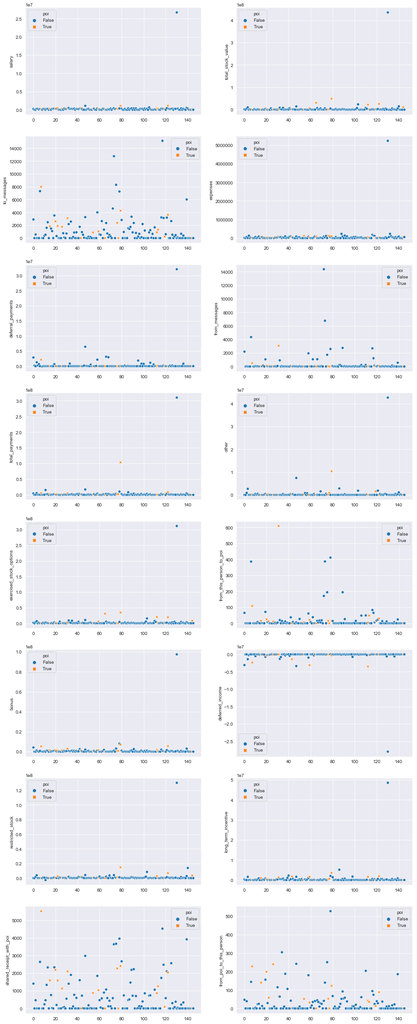

```python
fig, axs = plt.subplots(ncols=2, nrows=8, figsize=(15,40))

x_value = range(enron_data.shape[0])

nlin = 0
ncol = 0
for col in plot_cols:

    if nlin == 8:
        nlin = 0
        ncol = 1

    sns.scatterplot(data=enron_data, x=x_value, y=col, ax=axs[nlin, ncol], hue='poi', style='poi')
    nlin += 1
```

As shown in the plots above there's an explicit outlier - The TOTAL line that shouldn't be here.

```python
enron_data[enron_data.salary > 25000000]
```

|  | salary | to_messages | deferral_payments | total_payments | exercised_stock_options | bonus | restricted_stock | shared_receipt_with_poi | restricted_stock_deferred | total_stock_value | ... | loan_advances | from_messages | other | from_this_person_to_poi | poi | director_fees | deferred_income | long_term_incentive | email_address | from_poi_to_this_person |
| --- | --- | --- | --- | --- | --- | --- | --- | --- | --- | --- | --- | --- | --- | --- | --- | --- | --- | --- | --- | --- | --- |
| TOTAL | 26704229.0 | 0.0 | 32083396.0 | 309886585.0 | 311764000.0 | 97343619.0 | 130322299.0 | 0.0 | -7576788.0 | 434509511.0 | ... | 83925000.0 | 0.0 | 42667589.0 | 0.0 | False | 1398517.0 | -27992891.0 | 48521928.0 |  | 0.0 |

1 rows × 21 columns

Removing the identified outlier...

```python
enron_data.drop('TOTAL', axis=0, inplace=True)
```

Plots after the outlier's removal...

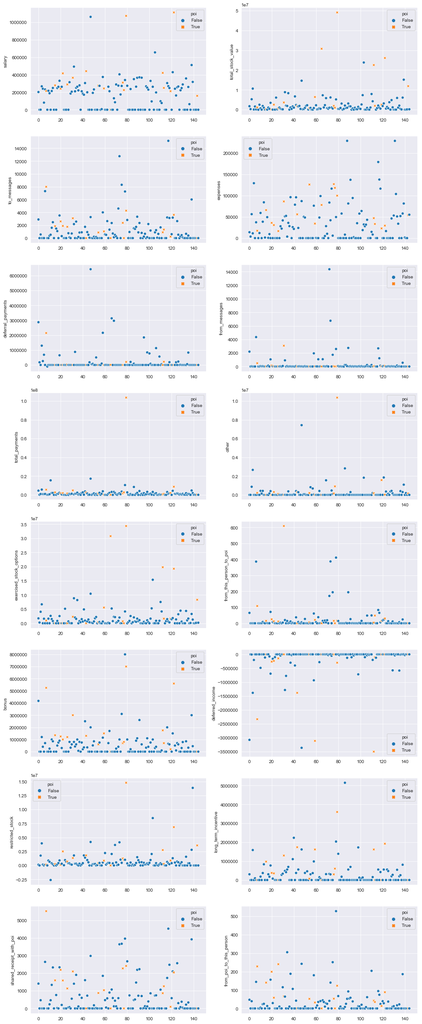

```python
fig, axs = plt.subplots(ncols=2, nrows=8, figsize=(15,40))

x_value = range(enron_data.shape[0])

nlin = 0
ncol = 0
for col in plot_cols:

    if nlin == 8:
        nlin = 0
        ncol = 1

    sns.scatterplot(data=enron_data, x=x_value, y=col, ax=axs[nlin, ncol], hue='poi', style='poi')
    nlin += 1
```

Observing the plots after removing the "TOTAL" line some names still stand out. Some of them were already labeled as POIs (SKILLING, LAY, BELDEN, HIRKO...) and that's why I'm not removing them from the dataset.

```python
enron_data[enron_data.salary > 1000000]
```

|  | salary | to_messages | deferral_payments | total_payments | exercised_stock_options | bonus | restricted_stock | shared_receipt_with_poi | restricted_stock_deferred | total_stock_value | ... | loan_advances | from_messages | other | from_this_person_to_poi | poi | director_fees | deferred_income | long_term_incentive | email_address | from_poi_to_this_person |
| --- | --- | --- | --- | --- | --- | --- | --- | --- | --- | --- | --- | --- | --- | --- | --- | --- | --- | --- | --- | --- | --- |
| FREVERT MARK A | 1060932.0 | 3275.0 | 6426990.0 | 17252530.0 | 10433518.0 | 2000000.0 | 4188667.0 | 2979.0 | 0.0 | 14622185.0 | ... | 2000000.0 | 21.0 | 7427621.0 | 6.0 | False | 0.0 | -3367011.0 | 1617011.0 | mark.frevert@enron.com | 242.0 |
| LAY KENNETH L | 1072321.0 | 4273.0 | 202911.0 | 103559793.0 | 34348384.0 | 7000000.0 | 14761694.0 | 2411.0 | 0.0 | 49110078.0 | ... | 81525000.0 | 36.0 | 10359729.0 | 16.0 | True | 0.0 | -300000.0 | 3600000.0 | kenneth.lay@enron.com | 123.0 |
| SKILLING JEFFREY K | 1111258.0 | 3627.0 | 0.0 | 8682716.0 | 19250000.0 | 5600000.0 | 6843672.0 | 2042.0 | 0.0 | 26093672.0 | ... | 0.0 | 108.0 | 22122.0 | 30.0 | True | 0.0 | 0.0 | 1920000.0 | jeff.skilling@enron.com | 88.0 |

3 rows × 21 columns

```python
enron_data[enron_data.bonus > 5000000]
```

|  | salary | to_messages | deferral_payments | total_payments | exercised_stock_options | bonus | restricted_stock | shared_receipt_with_poi | restricted_stock_deferred | total_stock_value | ... | loan_advances | from_messages | other | from_this_person_to_poi | poi | director_fees | deferred_income | long_term_incentive | email_address | from_poi_to_this_person |
| --- | --- | --- | --- | --- | --- | --- | --- | --- | --- | --- | --- | --- | --- | --- | --- | --- | --- | --- | --- | --- | --- |
| BELDEN TIMOTHY N | 213999.0 | 7991.0 | 2144013.0 | 5501630.0 | 953136.0 | 5249999.0 | 157569.0 | 5521.0 | 0.0 | 1110705.0 | ... | 0.0 | 484.0 | 210698.0 | 108.0 | True | 0.0 | -2334434.0 | 0.0 | tim.belden@enron.com | 228.0 |
| LAVORATO JOHN J | 339288.0 | 7259.0 | 0.0 | 10425757.0 | 4158995.0 | 8000000.0 | 1008149.0 | 3962.0 | 0.0 | 5167144.0 | ... | 0.0 | 2585.0 | 1552.0 | 411.0 | False | 0.0 | 0.0 | 2035380.0 | john.lavorato@enron.com | 528.0 |
| LAY KENNETH L | 1072321.0 | 4273.0 | 202911.0 | 103559793.0 | 34348384.0 | 7000000.0 | 14761694.0 | 2411.0 | 0.0 | 49110078.0 | ... | 81525000.0 | 36.0 | 10359729.0 | 16.0 | True | 0.0 | -300000.0 | 3600000.0 | kenneth.lay@enron.com | 123.0 |
| SKILLING JEFFREY K | 1111258.0 | 3627.0 | 0.0 | 8682716.0 | 19250000.0 | 5600000.0 | 6843672.0 | 2042.0 | 0.0 | 26093672.0 | ... | 0.0 | 108.0 | 22122.0 | 30.0 | True | 0.0 | 0.0 | 1920000.0 | jeff.skilling@enron.com | 88.0 |

4 rows × 21 columns

```python
enron_data[enron_data.total_payments > 100000000]
```

|  | salary | to_messages | deferral_payments | total_payments | exercised_stock_options | bonus | restricted_stock | shared_receipt_with_poi | restricted_stock_deferred | total_stock_value | ... | loan_advances | from_messages | other | from_this_person_to_poi | poi | director_fees | deferred_income | long_term_incentive | email_address | from_poi_to_this_person |
| --- | --- | --- | --- | --- | --- | --- | --- | --- | --- | --- | --- | --- | --- | --- | --- | --- | --- | --- | --- | --- | --- |
| LAY KENNETH L | 1072321.0 | 4273.0 | 202911.0 | 103559793.0 | 34348384.0 | 7000000.0 | 14761694.0 | 2411.0 | 0.0 | 49110078.0 | ... | 81525000.0 | 36.0 | 10359729.0 | 16.0 | True | 0.0 | -300000.0 | 3600000.0 | kenneth.lay@enron.com | 123.0 |

1 rows × 21 columns

# Feature Engineering

```python
orig_features = ['poi',
'salary',
'deferral_payments',
'total_payments',
'bonus',
'deferred_income',
'total_stock_value',
'expenses',
'exercised_stock_options',
'other',
'long_term_incentive',
'restricted_stock',
'to_messages',
'from_poi_to_this_person',
'from_messages',
'from_this_person_to_poi',
'shared_receipt_with_poi']

# Removed Features:

# loan_advances
# restricted_stock_deferred
# director_fees
# email_address
```

```python
enron_data['from_poi_ratio'] = enron_data.from_poi_to_this_person / enron_data.to_messages
enron_data['to_poi_ratio'] = enron_data.from_this_person_to_poi / enron_data.from_messages
enron_data.fillna(value=0, inplace=True)
```

```python
my_features = ['from_poi_ratio', 'to_poi_ratio']
```

Plotting the new features...

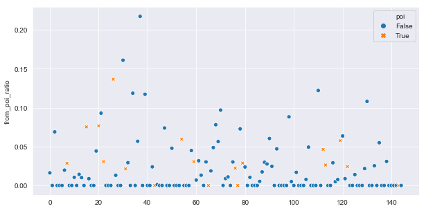

```python
plt.figure(figsize=(10,5))
sns.scatterplot(data=enron_data, x=x_value, y='from_poi_ratio', hue='poi', style='poi')
```

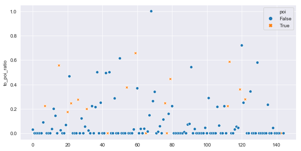

```python
plt.figure(figsize=(10,5))
sns.scatterplot(data=enron_data, x=x_value, y='to_poi_ratio', hue='poi', style='poi')
```

Returning the data to it's original type (dict)

```python
data_dict = enron_data.to_dict(orient='index')
```

# Classifiers / Validation

### Auxiliar Functions...

```python
'''

This is a copy of `test_classifier` found in tester.py.
I did not use the original function because I needed it to return the evaluated metrics instead of just printing them.

'''

def test_classifier(clf, dataset, feature_list, folds = 1000):

    data = featureFormat(dataset, feature_list, sort_keys = True)
    labels, features = targetFeatureSplit(data)
    cv = StratifiedShuffleSplit(labels, folds, random_state = 42)
    true_negatives = 0
    false_negatives = 0
    true_positives = 0
    false_positives = 0

    for train_idx, test_idx in cv:
        features_train = []
        features_test  = []
        labels_train   = []
        labels_test    = []
        for ii in train_idx:
            features_train.append( features[ii] )
            labels_train.append( labels[ii] )
        for jj in test_idx:
            features_test.append( features[jj] )
            labels_test.append( labels[jj] )

        ### fit the classifier using training set, and test on test set
        clf.fit(features_train, labels_train)
        predictions = clf.predict(features_test)
        for prediction, truth in zip(predictions, labels_test):
            if prediction == 0 and truth == 0:
                true_negatives += 1
            elif prediction == 0 and truth == 1:
                false_negatives += 1
            elif prediction == 1 and truth == 0:
                false_positives += 1
            elif prediction == 1 and truth == 1:
                true_positives += 1
            else:
                print "Warning: Found a predicted label not == 0 or 1."
                print "All predictions should take value 0 or 1."
                print "Evaluating performance for processed predictions:"
                break
    try:
        total_predictions = true_negatives + false_negatives + false_positives + true_positives
        accuracy = 1.0*(true_positives + true_negatives)/total_predictions
        precision = 1.0*true_positives/(true_positives+false_positives)
        recall = 1.0*true_positives/(true_positives+false_negatives)
        f1 = 2.0 * true_positives/(2*true_positives + false_positives+false_negatives)
        f2 = (1+2.0*2.0) * precision*recall/(4*precision + recall)
    except:
        accuracy=0
        precision=0
        recall = 0
        f1= 0
        f2 = 0

    return accuracy, precision, recall, f1, f2
```

```python
'''

    This function evaluates a classifier with gridsearch and returns
    the best classifier found. It also prints some important information
    during the process like the feature importances and the grid results

'''

def eval_classifier(classifier, features_list, selector=None, print_scores=True):

    grid_scoring = 'recall'
    sel = None
    features_aux = features_list[1:]
    feature_scores = []

    data = featureFormat(data_dict, features_list, sort_keys=True)
    labels, features = targetFeatureSplit(data)

    if selector:
        sel = selector['sel']
    else:
        selector = None

    # Setting up the pipeline
    pipe = Pipeline([('pre', MinMaxScaler()),
                     ('sel', sel),
                     ('clf', classifier['instance'])])

    # Gridsearch params
    param_grid = {}

    # If feature selection is enabled, set the params for the selector
    if selector:
        for key in selector['params']:
            param_grid['sel__'+key] = selector['params'][key]

    # Formatting the grid params w/ the pipeline step prefix
    for key in classifier['params']:
        param_grid['clf__'+key] = classifier['params'][key]

    # Performing Gridsearch
    grid = GridSearchCV(pipe, param_grid, scoring=grid_scoring, cv=StratifiedShuffleSplit(labels, 100, random_state=42), n_jobs=3).fit(features, labels)

    # If selected, print the gridsearch scores.
    if print_scores:
        print "Grid Result Means..."
        print ""

        for mean, params in sorted(zip(grid.cv_results_['mean_test_score'], grid.cv_results_['params']), key=lambda x:x[0]):
            print "Mean Test Score: %0.3f - Params: %r" % (mean, params)

    # Classifier Scores...
    accuracy, precision, recall, f1, f2 = test_classifier(grid.best_estimator_, data_dict, features_list)

    print ""
    print "Model Scores..."
    print ""

    print "Accuracy:", accuracy
    print "Precision:", precision
    print "Recall:", recall

    # If a feature selector is used, print the feature scores...
    if selector:
        print ""
        print "Feature Scores..."
        print ""

        for i in grid.best_estimator_.named_steps['sel'].get_support(True):
            feature_scores.append([features_aux[i], grid.best_estimator_.named_steps['sel'].scores_[i]])

        for feature in sorted(feature_scores, key = lambda x: x[1]):
            print "{} - Score: {}".format(feature[0], feature[1])

    print ""
    print "Best Estimator..."
    print ""
    print grid.best_estimator_

    return grid.best_estimator_
```

```python
# Default values for feature selection...
kbest = {'sel':SelectKBest(f_classif),'params':{'k':[2,6,10,14,'all']}}
```

## Naive Bayes

```python
clf = {'instance':GaussianNB(), 'params':{}}
```

### All Features

#### Original Features

```python
nb1 = eval_classifier(clf, features_list=orig_features)
```

```
Grid Result Means...

Mean Test Score: 0.290 - Params: {}

Model Scores...

Accuracy: 0.8304
Precision: 0.324967824968
Recall: 0.2525

Best Estimator...

Pipeline(memory=None,
     steps=[('pre', MinMaxScaler(copy=True, feature_range=(0, 1))), ('sel', None), ('clf', GaussianNB(priors=None))])
```

#### Original + Custom Features

```python
nb2 = eval_classifier(clf, features_list=orig_features+my_features)
```

```
Grid Result Means...

Mean Test Score: 0.275 - Params: {}

Model Scores...

Accuracy: 0.827733333333
Precision: 0.314249363868
Recall: 0.247

Best Estimator...

Pipeline(memory=None,
     steps=[('pre', MinMaxScaler(copy=True, feature_range=(0, 1))), ('sel', None), ('clf', GaussianNB(priors=None))])
```

With all the original features Naive Bayes scored .32 precision and .25 recall.  
When the custom features were added both precision and recall got worse, scoring .31 and .24.

### Feature Selection - SelectKBest

#### Original Features

```python
features_list = orig_features
nb3 = eval_classifier(clf, features_list, selector=kbest)
```

[output not shown]

#### Original + Custom Features

```python
features_list = orig_features+my_features
nb4 = eval_classifier(clf, features_list, selector=kbest)
```

```
Grid Result Means...

Mean Test Score: 0.185 - Params: {'sel__k': 2}
Mean Test Score: 0.275 - Params: {'sel__k': 'all'}
Mean Test Score: 0.325 - Params: {'sel__k': 6}
Mean Test Score: 0.345 - Params: {'sel__k': 14}
Mean Test Score: 0.365 - Params: {'sel__k': 10}

Model Scores...

Accuracy: 0.839
Precision: 0.377291543465
Recall: 0.319

Feature Scores...

long_term_incentive - Score: 5.66331492459
deferred_income - Score: 6.19466529169
shared_receipt_with_poi - Score: 7.06339857137
total_payments - Score: 8.50623857494
restricted_stock - Score: 8.61001146667
to_poi_ratio - Score: 13.8059501321
bonus - Score: 15.4914145509
salary - Score: 16.9609162406
total_stock_value - Score: 22.334566139
exercised_stock_options - Score: 22.846900557

Best Estimator...

Pipeline(memory=None,
     steps=[('pre', MinMaxScaler(copy=True, feature_range=(0, 1))), ('sel', SelectKBest(k=10, score_func=<function f_classif at 0x000000000C186748>)), ('clf', GaussianNB(priors=None))])
```

## Decision Tree

```python
clf = {'instance':DecisionTreeClassifier(),
       'params':{'min_samples_split':[2,5,8,12,16,20],
                 'max_depth':[2,5,8,12,15,20]}}
```

### All Features

#### Original Features

```python
features_list=orig_features
dt1 = eval_classifier(clf, features_list)
```

```
Grid Result Means...

Mean Test Score: 0.060 - Params: {'clf__max_depth': 2, 'clf__min_samples_split': 20}
Mean Test Score: 0.100 - Params: {'clf__max_depth': 2, 'clf__min_samples_split': 2}
Mean Test Score: 0.100 - Params: {'clf__max_depth': 2, 'clf__min_samples_split': 8}
Mean Test Score: 0.100 - Params: {'clf__max_depth': 2, 'clf__min_samples_split': 12}
Mean Test Score: 0.100 - Params: {'clf__max_depth': 2, 'clf__min_samples_split': 16}
Mean Test Score: 0.105 - Params: {'clf__max_depth': 2, 'clf__min_samples_split': 5}
Mean Test Score: 0.170 - Params: {'clf__max_depth': 5, 'clf__min_samples_split': 20}
Mean Test Score: 0.170 - Params: {'clf__max_depth': 8, 'clf__min_samples_split': 20}
Mean Test Score: 0.170 - Params: {'clf__max_depth': 12, 'clf__min_samples_split': 20}
Mean Test Score: 0.175 - Params: {'clf__max_depth': 15, 'clf__min_samples_split': 20}
Mean Test Score: 0.175 - Params: {'clf__max_depth': 20, 'clf__min_samples_split': 20}
Mean Test Score: 0.215 - Params: {'clf__max_depth': 12, 'clf__min_samples_split': 8}
Mean Test Score: 0.215 - Params: {'clf__max_depth': 15, 'clf__min_samples_split': 8}
Mean Test Score: 0.220 - Params: {'clf__max_depth': 5, 'clf__min_samples_split': 2}
Mean Test Score: 0.220 - Params: {'clf__max_depth': 5, 'clf__min_samples_split': 16}
Mean Test Score: 0.225 - Params: {'clf__max_depth': 5, 'clf__min_samples_split': 5}
Mean Test Score: 0.225 - Params: {'clf__max_depth': 5, 'clf__min_samples_split': 8}
Mean Test Score: 0.225 - Params: {'clf__max_depth': 8, 'clf__min_samples_split': 8}
Mean Test Score: 0.225 - Params: {'clf__max_depth': 12, 'clf__min_samples_split': 16}
Mean Test Score: 0.225 - Params: {'clf__max_depth': 15, 'clf__min_samples_split': 5}
Mean Test Score: 0.230 - Params: {'clf__max_depth': 5, 'clf__min_samples_split': 12}
Mean Test Score: 0.230 - Params: {'clf__max_depth': 8, 'clf__min_samples_split': 5}
Mean Test Score: 0.230 - Params: {'clf__max_depth': 12, 'clf__min_samples_split': 12}
Mean Test Score: 0.230 - Params: {'clf__max_depth': 15, 'clf__min_samples_split': 12}
Mean Test Score: 0.230 - Params: {'clf__max_depth': 15, 'clf__min_samples_split': 16}
Mean Test Score: 0.235 - Params: {'clf__max_depth': 8, 'clf__min_samples_split': 12}
Mean Test Score: 0.235 - Params: {'clf__max_depth': 8, 'clf__min_samples_split': 16}
Mean Test Score: 0.235 - Params: {'clf__max_depth': 15, 'clf__min_samples_split': 2}
Mean Test Score: 0.235 - Params: {'clf__max_depth': 20, 'clf__min_samples_split': 8}
Mean Test Score: 0.235 - Params: {'clf__max_depth': 20, 'clf__min_samples_split': 12}
Mean Test Score: 0.240 - Params: {'clf__max_depth': 12, 'clf__min_samples_split': 2}
Mean Test Score: 0.240 - Params: {'clf__max_depth': 20, 'clf__min_samples_split': 16}
Mean Test Score: 0.250 - Params: {'clf__max_depth': 8, 'clf__min_samples_split': 2}
Mean Test Score: 0.250 - Params: {'clf__max_depth': 12, 'clf__min_samples_split': 5}
Mean Test Score: 0.255 - Params: {'clf__max_depth': 20, 'clf__min_samples_split': 2}
Mean Test Score: 0.260 - Params: {'clf__max_depth': 20, 'clf__min_samples_split': 5}

Model Scores...

Accuracy: 0.8016
Precision: 0.230386740331
Recall: 0.2085

Best Estimator...

Pipeline(memory=None,
     steps=[('pre', MinMaxScaler(copy=True, feature_range=(0, 1))), ('sel', None), ('clf', DecisionTreeClassifier(class_weight=None, criterion='gini', max_depth=20,
            max_features=None, max_leaf_nodes=None,
            min_impurity_decrease=0.0, min_impurity_split=None,
            min_samples_leaf=1, min_samples_split=5,
            min_weight_fraction_leaf=0.0, presort=False, random_state=None,
            splitter='best'))])
```

#### Original + Custom Features

```python
features_list=orig_features+my_features
dt2 = eval_classifier(clf, features_list)
```

```
Grid Result Means...

Mean Test Score: 0.175 - Params: {'clf__max_depth': 2, 'clf__min_samples_split': 20}
Mean Test Score: 0.195 - Params: {'clf__max_depth': 2, 'clf__min_samples_split': 5}
Mean Test Score: 0.195 - Params: {'clf__max_depth': 2, 'clf__min_samples_split': 12}
Mean Test Score: 0.200 - Params: {'clf__max_depth': 2, 'clf__min_samples_split': 2}
Mean Test Score: 0.200 - Params: {'clf__max_depth': 2, 'clf__min_samples_split': 8}
Mean Test Score: 0.200 - Params: {'clf__max_depth': 2, 'clf__min_samples_split': 16}
Mean Test Score: 0.260 - Params: {'clf__max_depth': 15, 'clf__min_samples_split': 8}
Mean Test Score: 0.265 - Params: {'clf__max_depth': 15, 'clf__min_samples_split': 5}
Mean Test Score: 0.275 - Params: {'clf__max_depth': 12, 'clf__min_samples_split': 12}
Mean Test Score: 0.280 - Params: {'clf__max_depth': 5, 'clf__min_samples_split': 8}
Mean Test Score: 0.280 - Params: {'clf__max_depth': 8, 'clf__min_samples_split': 5}
Mean Test Score: 0.280 - Params: {'clf__max_depth': 20, 'clf__min_samples_split': 8}
Mean Test Score: 0.285 - Params: {'clf__max_depth': 5, 'clf__min_samples_split': 5}
Mean Test Score: 0.285 - Params: {'clf__max_depth': 8, 'clf__min_samples_split': 8}
Mean Test Score: 0.290 - Params: {'clf__max_depth': 5, 'clf__min_samples_split': 12}
Mean Test Score: 0.290 - Params: {'clf__max_depth': 8, 'clf__min_samples_split': 12}
Mean Test Score: 0.290 - Params: {'clf__max_depth': 12, 'clf__min_samples_split': 8}
Mean Test Score: 0.290 - Params: {'clf__max_depth': 20, 'clf__min_samples_split': 12}
Mean Test Score: 0.295 - Params: {'clf__max_depth': 12, 'clf__min_samples_split': 5}
Mean Test Score: 0.295 - Params: {'clf__max_depth': 15, 'clf__min_samples_split': 12}
Mean Test Score: 0.295 - Params: {'clf__max_depth': 20, 'clf__min_samples_split': 5}
Mean Test Score: 0.300 - Params: {'clf__max_depth': 5, 'clf__min_samples_split': 2}
Mean Test Score: 0.300 - Params: {'clf__max_depth': 12, 'clf__min_samples_split': 20}
Mean Test Score: 0.305 - Params: {'clf__max_depth': 8, 'clf__min_samples_split': 20}
Mean Test Score: 0.305 - Params: {'clf__max_depth': 20, 'clf__min_samples_split': 20}
Mean Test Score: 0.310 - Params: {'clf__max_depth': 15, 'clf__min_samples_split': 20}
Mean Test Score: 0.310 - Params: {'clf__max_depth': 20, 'clf__min_samples_split': 2}
Mean Test Score: 0.315 - Params: {'clf__max_depth': 15, 'clf__min_samples_split': 2}
Mean Test Score: 0.320 - Params: {'clf__max_depth': 5, 'clf__min_samples_split': 20}
Mean Test Score: 0.320 - Params: {'clf__max_depth': 8, 'clf__min_samples_split': 2}
Mean Test Score: 0.320 - Params: {'clf__max_depth': 12, 'clf__min_samples_split': 2}
Mean Test Score: 0.345 - Params: {'clf__max_depth': 8, 'clf__min_samples_split': 16}
Mean Test Score: 0.345 - Params: {'clf__max_depth': 12, 'clf__min_samples_split': 16}
Mean Test Score: 0.345 - Params: {'clf__max_depth': 15, 'clf__min_samples_split': 16}
Mean Test Score: 0.345 - Params: {'clf__max_depth': 20, 'clf__min_samples_split': 16}
Mean Test Score: 0.355 - Params: {'clf__max_depth': 5, 'clf__min_samples_split': 16}

Model Scores...

Accuracy: 0.829133333333
Precision: 0.347590687602
Recall: 0.321

Best Estimator...

Pipeline(memory=None,
     steps=[('pre', MinMaxScaler(copy=True, feature_range=(0, 1))), ('sel', None), ('clf', DecisionTreeClassifier(class_weight=None, criterion='gini', max_depth=5,
            max_features=None, max_leaf_nodes=None,
            min_impurity_decrease=0.0, min_impurity_split=None,
            min_samples_leaf=1, min_samples_split=16,
            min_weight_fraction_leaf=0.0, presort=False, random_state=None,
            splitter='best'))])
```

With all the original features the Decision Tree scored .23 precision and .20 recall.  
When the custom features were added both the precision and recall got higher, scoring .34 and .32.

### Feature Selection - SelectKBest

#### Original Features

```python
features_list = orig_features
dt3 = eval_classifier(clf, features_list, selector=kbest)
```

```
Grid Result Means...

Mean Test Score: 0.060 - Params: {'clf__max_depth': 2, 'sel__k': 10, 'clf__min_samples_split': 20}
Mean Test Score: 0.060 - Params: {'clf__max_depth': 2, 'sel__k': 'all', 'clf__min_samples_split': 20}
Mean Test Score: 0.065 - Params: {'clf__max_depth': 2, 'sel__k': 14, 'clf__min_samples_split': 20}
Mean Test Score: 0.085 - Params: {'clf__max_depth': 2, 'sel__k': 6, 'clf__min_samples_split': 20}
Mean Test Score: 0.095 - Params: {'clf__max_depth': 12, 'sel__k': 6, 'clf__min_samples_split': 20}
Mean Test Score: 0.095 - Params: {'clf__max_depth': 15, 'sel__k': 6, 'clf__min_samples_split': 20}
Mean Test Score: 0.095 - Params: {'clf__max_depth': 20, 'sel__k': 6, 'clf__min_samples_split': 20}
Mean Test Score: 0.100 - Params: {'clf__max_depth': 2, 'sel__k': 14, 'clf__min_samples_split': 2}
Mean Test Score: 0.100 - Params: {'clf__max_depth': 2, 'sel__k': 2, 'clf__min_samples_split': 5}
Mean Test Score: 0.100 - Params: {'clf__max_depth': 2, 'sel__k': 14, 'clf__min_samples_split': 5}
Mean Test Score: 0.100 - Params: {'clf__max_depth': 2, 'sel__k': 2, 'clf__min_samples_split': 8}
Mean Test Score: 0.100 - Params: {'clf__max_depth': 2, 'sel__k': 'all', 'clf__min_samples_split': 8}
Mean Test Score: 0.100 - Params: {'clf__max_depth': 2, 'sel__k': 14, 'clf__min_samples_split': 12}
Mean Test Score: 0.100 - Params: {'clf__max_depth': 5, 'sel__k': 6, 'clf__min_samples_split': 20}
Mean Test Score: 0.100 - Params: {'clf__max_depth': 5, 'sel__k': 10, 'clf__min_samples_split': 20}
Mean Test Score: 0.100 - Params: {'clf__max_depth': 8, 'sel__k': 10, 'clf__min_samples_split': 20}
Mean Test Score: 0.100 - Params: {'clf__max_depth': 12, 'sel__k': 10, 'clf__min_samples_split': 20}
Mean Test Score: 0.100 - Params: {'clf__max_depth': 15, 'sel__k': 10, 'clf__min_samples_split': 20}
Mean Test Score: 0.100 - Params: {'clf__max_depth': 20, 'sel__k': 10, 'clf__min_samples_split': 20}
Mean Test Score: 0.105 - Params: {'clf__max_depth': 2, 'sel__k': 'all', 'clf__min_samples_split': 2}
Mean Test Score: 0.105 - Params: {'clf__max_depth': 2, 'sel__k': 14, 'clf__min_samples_split': 8}
Mean Test Score: 0.105 - Params: {'clf__max_depth': 2, 'sel__k': 10, 'clf__min_samples_split': 12}
Mean Test Score: 0.105 - Params: {'clf__max_depth': 2, 'sel__k': 2, 'clf__min_samples_split': 16}
Mean Test Score: 0.105 - Params: {'clf__max_depth': 2, 'sel__k': 'all', 'clf__min_samples_split': 16}
Mean Test Score: 0.105 - Params: {'clf__max_depth': 8, 'sel__k': 6, 'clf__min_samples_split': 20}
Mean Test Score: 0.110 - Params: {'clf__max_depth': 2, 'sel__k': 2, 'clf__min_samples_split': 2}
Mean Test Score: 0.110 - Params: {'clf__max_depth': 2, 'sel__k': 10, 'clf__min_samples_split': 2}
Mean Test Score: 0.110 - Params: {'clf__max_depth': 2, 'sel__k': 10, 'clf__min_samples_split': 5}
Mean Test Score: 0.110 - Params: {'clf__max_depth': 2, 'sel__k': 'all', 'clf__min_samples_split': 5}
Mean Test Score: 0.110 - Params: {'clf__max_depth': 2, 'sel__k': 2, 'clf__min_samples_split': 12}
Mean Test Score: 0.110 - Params: {'clf__max_depth': 2, 'sel__k': 'all', 'clf__min_samples_split': 12}
Mean Test Score: 0.110 - Params: {'clf__max_depth': 2, 'sel__k': 14, 'clf__min_samples_split': 16}
Mean Test Score: 0.110 - Params: {'clf__max_depth': 2, 'sel__k': 2, 'clf__min_samples_split': 20}
Mean Test Score: 0.115 - Params: {'clf__max_depth': 2, 'sel__k': 10, 'clf__min_samples_split': 8}
Mean Test Score: 0.115 - Params: {'clf__max_depth': 2, 'sel__k': 10, 'clf__min_samples_split': 16}
Mean Test Score: 0.120 - Params: {'clf__max_depth': 2, 'sel__k': 6, 'clf__min_samples_split': 2}
Mean Test Score: 0.120 - Params: {'clf__max_depth': 2, 'sel__k': 6, 'clf__min_samples_split': 12}
Mean Test Score: 0.120 - Params: {'clf__max_depth': 2, 'sel__k': 6, 'clf__min_samples_split': 16}
```

[output cut: 150 more lines]

```

total_payments - Score: 8.50623857494
restricted_stock - Score: 8.61001146667
bonus - Score: 15.4914145509
salary - Score: 16.9609162406
total_stock_value - Score: 22.334566139
exercised_stock_options - Score: 22.846900557

Best Estimator...

Pipeline(memory=None,
     steps=[('pre', MinMaxScaler(copy=True, feature_range=(0, 1))), ('sel', SelectKBest(k=6, score_func=<function f_classif at 0x000000000C186748>)), ('clf', DecisionTreeClassifier(class_weight=None, criterion='gini', max_depth=20,
            max_features=None, max_leaf_nodes=None,
            min_impur...      min_weight_fraction_leaf=0.0, presort=False, random_state=None,
            splitter='best'))])
```

#### Original + Custom Features

```python
features_list = orig_features+my_features
dt4 = eval_classifier(clf, features_list, selector=kbest)
```

```
Grid Result Means...

Mean Test Score: 0.125 - Params: {'clf__max_depth': 2, 'sel__k': 2, 'clf__min_samples_split': 8}
Mean Test Score: 0.130 - Params: {'clf__max_depth': 2, 'sel__k': 2, 'clf__min_samples_split': 2}
Mean Test Score: 0.130 - Params: {'clf__max_depth': 2, 'sel__k': 2, 'clf__min_samples_split': 12}
Mean Test Score: 0.130 - Params: {'clf__max_depth': 2, 'sel__k': 2, 'clf__min_samples_split': 16}
Mean Test Score: 0.135 - Params: {'clf__max_depth': 2, 'sel__k': 2, 'clf__min_samples_split': 5}
Mean Test Score: 0.140 - Params: {'clf__max_depth': 2, 'sel__k': 2, 'clf__min_samples_split': 20}
Mean Test Score: 0.145 - Params: {'clf__max_depth': 2, 'sel__k': 6, 'clf__min_samples_split': 20}
Mean Test Score: 0.150 - Params: {'clf__max_depth': 5, 'sel__k': 2, 'clf__min_samples_split': 2}
Mean Test Score: 0.150 - Params: {'clf__max_depth': 5, 'sel__k': 2, 'clf__min_samples_split': 16}
Mean Test Score: 0.150 - Params: {'clf__max_depth': 5, 'sel__k': 2, 'clf__min_samples_split': 20}
Mean Test Score: 0.150 - Params: {'clf__max_depth': 12, 'sel__k': 2, 'clf__min_samples_split': 2}
Mean Test Score: 0.155 - Params: {'clf__max_depth': 2, 'sel__k': 6, 'clf__min_samples_split': 16}
Mean Test Score: 0.155 - Params: {'clf__max_depth': 5, 'sel__k': 2, 'clf__min_samples_split': 8}
Mean Test Score: 0.155 - Params: {'clf__max_depth': 8, 'sel__k': 2, 'clf__min_samples_split': 8}
Mean Test Score: 0.155 - Params: {'clf__max_depth': 8, 'sel__k': 2, 'clf__min_samples_split': 16}
Mean Test Score: 0.155 - Params: {'clf__max_depth': 8, 'sel__k': 2, 'clf__min_samples_split': 20}
Mean Test Score: 0.155 - Params: {'clf__max_depth': 15, 'sel__k': 2, 'clf__min_samples_split': 20}
Mean Test Score: 0.160 - Params: {'clf__max_depth': 2, 'sel__k': 6, 'clf__min_samples_split': 2}
Mean Test Score: 0.160 - Params: {'clf__max_depth': 2, 'sel__k': 6, 'clf__min_samples_split': 5}
Mean Test Score: 0.160 - Params: {'clf__max_depth': 5, 'sel__k': 2, 'clf__min_samples_split': 5}
Mean Test Score: 0.160 - Params: {'clf__max_depth': 5, 'sel__k': 2, 'clf__min_samples_split': 12}
Mean Test Score: 0.160 - Params: {'clf__max_depth': 12, 'sel__k': 2, 'clf__min_samples_split': 12}
Mean Test Score: 0.160 - Params: {'clf__max_depth': 12, 'sel__k': 2, 'clf__min_samples_split': 16}
Mean Test Score: 0.160 - Params: {'clf__max_depth': 12, 'sel__k': 2, 'clf__min_samples_split': 20}
Mean Test Score: 0.160 - Params: {'clf__max_depth': 15, 'sel__k': 2, 'clf__min_samples_split': 16}
Mean Test Score: 0.160 - Params: {'clf__max_depth': 20, 'sel__k': 2, 'clf__min_samples_split': 8}
Mean Test Score: 0.160 - Params: {'clf__max_depth': 20, 'sel__k': 2, 'clf__min_samples_split': 16}
Mean Test Score: 0.160 - Params: {'clf__max_depth': 20, 'sel__k': 2, 'clf__min_samples_split': 20}
Mean Test Score: 0.165 - Params: {'clf__max_depth': 2, 'sel__k': 6, 'clf__min_samples_split': 8}
Mean Test Score: 0.165 - Params: {'clf__max_depth': 2, 'sel__k': 6, 'clf__min_samples_split': 12}
Mean Test Score: 0.165 - Params: {'clf__max_depth': 8, 'sel__k': 2, 'clf__min_samples_split': 2}
Mean Test Score: 0.165 - Params: {'clf__max_depth': 12, 'sel__k': 2, 'clf__min_samples_split': 5}
Mean Test Score: 0.165 - Params: {'clf__max_depth': 15, 'sel__k': 2, 'clf__min_samples_split': 2}
Mean Test Score: 0.165 - Params: {'clf__max_depth': 15, 'sel__k': 2, 'clf__min_samples_split': 12}
Mean Test Score: 0.170 - Params: {'clf__max_depth': 8, 'sel__k': 2, 'clf__min_samples_split': 12}
Mean Test Score: 0.170 - Params: {'clf__max_depth': 12, 'sel__k': 2, 'clf__min_samples_split': 8}
Mean Test Score: 0.170 - Params: {'clf__max_depth': 20, 'sel__k': 2, 'clf__min_samples_split': 12}
Mean Test Score: 0.175 - Params: {'clf__max_depth': 2, 'sel__k': 10, 'clf__min_samples_split': 20}
```

[output cut: 158 more lines]

```
total_payments - Score: 8.50623857494
restricted_stock - Score: 8.61001146667
to_poi_ratio - Score: 13.8059501321
bonus - Score: 15.4914145509
salary - Score: 16.9609162406
total_stock_value - Score: 22.334566139
exercised_stock_options - Score: 22.846900557

Best Estimator...

Pipeline(memory=None,
     steps=[('pre', MinMaxScaler(copy=True, feature_range=(0, 1))), ('sel', SelectKBest(k=14, score_func=<function f_classif at 0x000000000C186748>)), ('clf', DecisionTreeClassifier(class_weight=None, criterion='gini', max_depth=12,
            max_features=None, max_leaf_nodes=None,
            min_impu...      min_weight_fraction_leaf=0.0, presort=False, random_state=None,
            splitter='best'))])
```

When using feature selection, the Decision Tree scored .27 precision and .25 recall with the original features only.  
When the custom features were added to the model the precision and the recall scored .32 and .32 respectively.

## KNN

```python
clf = {'instance':KNeighborsClassifier(),
       'params':{'n_neighbors':[2,5,8,10],
                 'p':[1,2,3,4]}}
```

### All Features

#### Original Features

```python
knn1 = eval_classifier(clf, orig_features)
```

```
Grid Result Means...

Mean Test Score: 0.000 - Params: {'clf__p': 1, 'clf__n_neighbors': 8}
Mean Test Score: 0.000 - Params: {'clf__p': 2, 'clf__n_neighbors': 8}
Mean Test Score: 0.000 - Params: {'clf__p': 3, 'clf__n_neighbors': 8}
Mean Test Score: 0.000 - Params: {'clf__p': 4, 'clf__n_neighbors': 8}
Mean Test Score: 0.000 - Params: {'clf__p': 1, 'clf__n_neighbors': 10}
Mean Test Score: 0.000 - Params: {'clf__p': 2, 'clf__n_neighbors': 10}
Mean Test Score: 0.000 - Params: {'clf__p': 3, 'clf__n_neighbors': 10}
Mean Test Score: 0.000 - Params: {'clf__p': 4, 'clf__n_neighbors': 10}
Mean Test Score: 0.020 - Params: {'clf__p': 4, 'clf__n_neighbors': 5}
Mean Test Score: 0.025 - Params: {'clf__p': 2, 'clf__n_neighbors': 5}
Mean Test Score: 0.040 - Params: {'clf__p': 3, 'clf__n_neighbors': 5}
Mean Test Score: 0.065 - Params: {'clf__p': 4, 'clf__n_neighbors': 2}
Mean Test Score: 0.085 - Params: {'clf__p': 1, 'clf__n_neighbors': 5}
Mean Test Score: 0.115 - Params: {'clf__p': 3, 'clf__n_neighbors': 2}
Mean Test Score: 0.125 - Params: {'clf__p': 1, 'clf__n_neighbors': 2}
Mean Test Score: 0.125 - Params: {'clf__p': 2, 'clf__n_neighbors': 2}

Model Scores...

Accuracy: 0.868
Precision: 0.526315789474
Recall: 0.1

Best Estimator...

Pipeline(memory=None,
     steps=[('pre', MinMaxScaler(copy=True, feature_range=(0, 1))), ('sel', None), ('clf', KNeighborsClassifier(algorithm='auto', leaf_size=30, metric='minkowski',
           metric_params=None, n_jobs=1, n_neighbors=2, p=1,
           weights='uniform'))])
```

#### Original + Custom Features

```python
knn2 = eval_classifier(clf, features_list=orig_features+my_features)
```

```
Grid Result Means...

Mean Test Score: 0.000 - Params: {'clf__p': 1, 'clf__n_neighbors': 8}
Mean Test Score: 0.000 - Params: {'clf__p': 2, 'clf__n_neighbors': 8}
Mean Test Score: 0.000 - Params: {'clf__p': 4, 'clf__n_neighbors': 8}
Mean Test Score: 0.000 - Params: {'clf__p': 1, 'clf__n_neighbors': 10}
Mean Test Score: 0.000 - Params: {'clf__p': 2, 'clf__n_neighbors': 10}
Mean Test Score: 0.000 - Params: {'clf__p': 3, 'clf__n_neighbors': 10}
Mean Test Score: 0.000 - Params: {'clf__p': 4, 'clf__n_neighbors': 10}
Mean Test Score: 0.010 - Params: {'clf__p': 3, 'clf__n_neighbors': 8}
Mean Test Score: 0.015 - Params: {'clf__p': 3, 'clf__n_neighbors': 2}
Mean Test Score: 0.020 - Params: {'clf__p': 2, 'clf__n_neighbors': 2}
Mean Test Score: 0.030 - Params: {'clf__p': 3, 'clf__n_neighbors': 5}
Mean Test Score: 0.035 - Params: {'clf__p': 4, 'clf__n_neighbors': 2}
Mean Test Score: 0.040 - Params: {'clf__p': 4, 'clf__n_neighbors': 5}
Mean Test Score: 0.085 - Params: {'clf__p': 1, 'clf__n_neighbors': 2}
Mean Test Score: 0.085 - Params: {'clf__p': 2, 'clf__n_neighbors': 5}
Mean Test Score: 0.125 - Params: {'clf__p': 1, 'clf__n_neighbors': 5}

Model Scores...

Accuracy: 0.868733333333
Precision: 0.53734939759
Recall: 0.1115

Best Estimator...

Pipeline(memory=None,
     steps=[('pre', MinMaxScaler(copy=True, feature_range=(0, 1))), ('sel', None), ('clf', KNeighborsClassifier(algorithm='auto', leaf_size=30, metric='minkowski',
           metric_params=None, n_jobs=1, n_neighbors=5, p=1,
           weights='uniform'))])
```

With all the original features, KNN scored the best precision so far with .52 but the worst recall with only 0.1.  
When the custom features were added, both precision and recall got a little better (.53 and .11).

### Feature Selection - SelectKBest

#### Original Features

```python
features_list = orig_features
knn3 = eval_classifier(clf, features_list, selector=kbest)
```

```
Grid Result Means...

Mean Test Score: 0.000 - Params: {'clf__p': 1, 'sel__k': 2, 'clf__n_neighbors': 8}
Mean Test Score: 0.000 - Params: {'clf__p': 1, 'sel__k': 6, 'clf__n_neighbors': 8}
Mean Test Score: 0.000 - Params: {'clf__p': 1, 'sel__k': 10, 'clf__n_neighbors': 8}
Mean Test Score: 0.000 - Params: {'clf__p': 1, 'sel__k': 14, 'clf__n_neighbors': 8}
Mean Test Score: 0.000 - Params: {'clf__p': 1, 'sel__k': 'all', 'clf__n_neighbors': 8}
Mean Test Score: 0.000 - Params: {'clf__p': 2, 'sel__k': 2, 'clf__n_neighbors': 8}
Mean Test Score: 0.000 - Params: {'clf__p': 2, 'sel__k': 6, 'clf__n_neighbors': 8}
Mean Test Score: 0.000 - Params: {'clf__p': 2, 'sel__k': 10, 'clf__n_neighbors': 8}
Mean Test Score: 0.000 - Params: {'clf__p': 2, 'sel__k': 14, 'clf__n_neighbors': 8}
Mean Test Score: 0.000 - Params: {'clf__p': 2, 'sel__k': 'all', 'clf__n_neighbors': 8}
Mean Test Score: 0.000 - Params: {'clf__p': 3, 'sel__k': 2, 'clf__n_neighbors': 8}
Mean Test Score: 0.000 - Params: {'clf__p': 3, 'sel__k': 6, 'clf__n_neighbors': 8}
Mean Test Score: 0.000 - Params: {'clf__p': 3, 'sel__k': 10, 'clf__n_neighbors': 8}
Mean Test Score: 0.000 - Params: {'clf__p': 3, 'sel__k': 14, 'clf__n_neighbors': 8}
Mean Test Score: 0.000 - Params: {'clf__p': 3, 'sel__k': 'all', 'clf__n_neighbors': 8}
Mean Test Score: 0.000 - Params: {'clf__p': 4, 'sel__k': 6, 'clf__n_neighbors': 8}
Mean Test Score: 0.000 - Params: {'clf__p': 4, 'sel__k': 10, 'clf__n_neighbors': 8}
Mean Test Score: 0.000 - Params: {'clf__p': 4, 'sel__k': 14, 'clf__n_neighbors': 8}
Mean Test Score: 0.000 - Params: {'clf__p': 4, 'sel__k': 'all', 'clf__n_neighbors': 8}
Mean Test Score: 0.000 - Params: {'clf__p': 1, 'sel__k': 2, 'clf__n_neighbors': 10}
Mean Test Score: 0.000 - Params: {'clf__p': 1, 'sel__k': 6, 'clf__n_neighbors': 10}
Mean Test Score: 0.000 - Params: {'clf__p': 1, 'sel__k': 10, 'clf__n_neighbors': 10}
Mean Test Score: 0.000 - Params: {'clf__p': 1, 'sel__k': 14, 'clf__n_neighbors': 10}
Mean Test Score: 0.000 - Params: {'clf__p': 1, 'sel__k': 'all', 'clf__n_neighbors': 10}
Mean Test Score: 0.000 - Params: {'clf__p': 2, 'sel__k': 2, 'clf__n_neighbors': 10}
Mean Test Score: 0.000 - Params: {'clf__p': 2, 'sel__k': 6, 'clf__n_neighbors': 10}
Mean Test Score: 0.000 - Params: {'clf__p': 2, 'sel__k': 10, 'clf__n_neighbors': 10}
Mean Test Score: 0.000 - Params: {'clf__p': 2, 'sel__k': 14, 'clf__n_neighbors': 10}
Mean Test Score: 0.000 - Params: {'clf__p': 2, 'sel__k': 'all', 'clf__n_neighbors': 10}
Mean Test Score: 0.000 - Params: {'clf__p': 3, 'sel__k': 2, 'clf__n_neighbors': 10}
Mean Test Score: 0.000 - Params: {'clf__p': 3, 'sel__k': 6, 'clf__n_neighbors': 10}
Mean Test Score: 0.000 - Params: {'clf__p': 3, 'sel__k': 10, 'clf__n_neighbors': 10}
Mean Test Score: 0.000 - Params: {'clf__p': 3, 'sel__k': 14, 'clf__n_neighbors': 10}
Mean Test Score: 0.000 - Params: {'clf__p': 3, 'sel__k': 'all', 'clf__n_neighbors': 10}
Mean Test Score: 0.000 - Params: {'clf__p': 4, 'sel__k': 2, 'clf__n_neighbors': 10}
Mean Test Score: 0.000 - Params: {'clf__p': 4, 'sel__k': 6, 'clf__n_neighbors': 10}
Mean Test Score: 0.000 - Params: {'clf__p': 4, 'sel__k': 10, 'clf__n_neighbors': 10}
Mean Test Score: 0.000 - Params: {'clf__p': 4, 'sel__k': 14, 'clf__n_neighbors': 10}
```

[output cut: 45 more lines]

```
Accuracy: 0.8724
Precision: 0.559392265193
Recall: 0.2025

Feature Scores...

total_stock_value - Score: 22.334566139
exercised_stock_options - Score: 22.846900557

Best Estimator...

Pipeline(memory=None,
     steps=[('pre', MinMaxScaler(copy=True, feature_range=(0, 1))), ('sel', SelectKBest(k=2, score_func=<function f_classif at 0x000000000C186748>)), ('clf', KNeighborsClassifier(algorithm='auto', leaf_size=30, metric='minkowski',
           metric_params=None, n_jobs=1, n_neighbors=5, p=1,
           weights='uniform'))])
```

#### Original + Custom Features

```python
features_list = orig_features+my_features
knn4 = eval_classifier(clf, features_list, selector=kbest)
```

```
Grid Result Means...

Mean Test Score: 0.000 - Params: {'clf__p': 1, 'sel__k': 2, 'clf__n_neighbors': 8}
Mean Test Score: 0.000 - Params: {'clf__p': 1, 'sel__k': 14, 'clf__n_neighbors': 8}
Mean Test Score: 0.000 - Params: {'clf__p': 1, 'sel__k': 'all', 'clf__n_neighbors': 8}
Mean Test Score: 0.000 - Params: {'clf__p': 2, 'sel__k': 2, 'clf__n_neighbors': 8}
Mean Test Score: 0.000 - Params: {'clf__p': 2, 'sel__k': 6, 'clf__n_neighbors': 8}
Mean Test Score: 0.000 - Params: {'clf__p': 2, 'sel__k': 10, 'clf__n_neighbors': 8}
Mean Test Score: 0.000 - Params: {'clf__p': 2, 'sel__k': 14, 'clf__n_neighbors': 8}
Mean Test Score: 0.000 - Params: {'clf__p': 2, 'sel__k': 'all', 'clf__n_neighbors': 8}
Mean Test Score: 0.000 - Params: {'clf__p': 3, 'sel__k': 2, 'clf__n_neighbors': 8}
Mean Test Score: 0.000 - Params: {'clf__p': 3, 'sel__k': 6, 'clf__n_neighbors': 8}
Mean Test Score: 0.000 - Params: {'clf__p': 3, 'sel__k': 10, 'clf__n_neighbors': 8}
Mean Test Score: 0.000 - Params: {'clf__p': 3, 'sel__k': 14, 'clf__n_neighbors': 8}
Mean Test Score: 0.000 - Params: {'clf__p': 4, 'sel__k': 6, 'clf__n_neighbors': 8}
Mean Test Score: 0.000 - Params: {'clf__p': 4, 'sel__k': 10, 'clf__n_neighbors': 8}
Mean Test Score: 0.000 - Params: {'clf__p': 4, 'sel__k': 14, 'clf__n_neighbors': 8}
Mean Test Score: 0.000 - Params: {'clf__p': 4, 'sel__k': 'all', 'clf__n_neighbors': 8}
Mean Test Score: 0.000 - Params: {'clf__p': 1, 'sel__k': 2, 'clf__n_neighbors': 10}
Mean Test Score: 0.000 - Params: {'clf__p': 1, 'sel__k': 6, 'clf__n_neighbors': 10}
Mean Test Score: 0.000 - Params: {'clf__p': 1, 'sel__k': 10, 'clf__n_neighbors': 10}
Mean Test Score: 0.000 - Params: {'clf__p': 1, 'sel__k': 14, 'clf__n_neighbors': 10}
Mean Test Score: 0.000 - Params: {'clf__p': 1, 'sel__k': 'all', 'clf__n_neighbors': 10}
Mean Test Score: 0.000 - Params: {'clf__p': 2, 'sel__k': 2, 'clf__n_neighbors': 10}
Mean Test Score: 0.000 - Params: {'clf__p': 2, 'sel__k': 10, 'clf__n_neighbors': 10}
Mean Test Score: 0.000 - Params: {'clf__p': 2, 'sel__k': 14, 'clf__n_neighbors': 10}
Mean Test Score: 0.000 - Params: {'clf__p': 2, 'sel__k': 'all', 'clf__n_neighbors': 10}
Mean Test Score: 0.000 - Params: {'clf__p': 3, 'sel__k': 2, 'clf__n_neighbors': 10}
Mean Test Score: 0.000 - Params: {'clf__p': 3, 'sel__k': 6, 'clf__n_neighbors': 10}
Mean Test Score: 0.000 - Params: {'clf__p': 3, 'sel__k': 10, 'clf__n_neighbors': 10}
Mean Test Score: 0.000 - Params: {'clf__p': 3, 'sel__k': 14, 'clf__n_neighbors': 10}
Mean Test Score: 0.000 - Params: {'clf__p': 3, 'sel__k': 'all', 'clf__n_neighbors': 10}
Mean Test Score: 0.000 - Params: {'clf__p': 4, 'sel__k': 2, 'clf__n_neighbors': 10}
Mean Test Score: 0.000 - Params: {'clf__p': 4, 'sel__k': 6, 'clf__n_neighbors': 10}
Mean Test Score: 0.000 - Params: {'clf__p': 4, 'sel__k': 10, 'clf__n_neighbors': 10}
Mean Test Score: 0.000 - Params: {'clf__p': 4, 'sel__k': 14, 'clf__n_neighbors': 10}
Mean Test Score: 0.000 - Params: {'clf__p': 4, 'sel__k': 'all', 'clf__n_neighbors': 10}
Mean Test Score: 0.005 - Params: {'clf__p': 1, 'sel__k': 6, 'clf__n_neighbors': 8}
Mean Test Score: 0.005 - Params: {'clf__p': 1, 'sel__k': 10, 'clf__n_neighbors': 8}
Mean Test Score: 0.005 - Params: {'clf__p': 4, 'sel__k': 2, 'clf__n_neighbors': 8}
```

[output cut: 45 more lines]

```
Accuracy: 0.868533333333
Precision: 0.519283746556
Recall: 0.1885

Feature Scores...

total_stock_value - Score: 22.334566139
exercised_stock_options - Score: 22.846900557

Best Estimator...

Pipeline(memory=None,
     steps=[('pre', MinMaxScaler(copy=True, feature_range=(0, 1))), ('sel', SelectKBest(k=2, score_func=<function f_classif at 0x000000000C186748>)), ('clf', KNeighborsClassifier(algorithm='auto', leaf_size=30, metric='minkowski',
           metric_params=None, n_jobs=1, n_neighbors=5, p=1,
           weights='uniform'))])
```

When using feature selection, KNN scored .55 precision and .20 recall. This is an interesting precision, but unfortunately the recall isn't higher than .30 and so it doesn't attend the project's requirements.  
When the custom features were added a small drop in both precision and recall was observed: .51 precision and .18 recall.

## SVM

```python
clf = {'instance':SVC(),
       'params':{'kernel':['rbf'],
                 'C':[0.001, 0.01, 0.1, 1.,10.,100],
                 'gamma':[1000, 100, 10, 1,0.1,0.01,0.001,0.0001]}}
```

### All Features

#### Original Features

```python
svm1 = eval_classifier(clf, features_list=orig_features)
```

```
Grid Result Means...

Mean Test Score: 0.000 - Params: {'clf__gamma': 1000, 'clf__C': 0.001, 'clf__kernel': 'rbf'}
Mean Test Score: 0.000 - Params: {'clf__gamma': 100, 'clf__C': 0.001, 'clf__kernel': 'rbf'}
Mean Test Score: 0.000 - Params: {'clf__gamma': 10, 'clf__C': 0.001, 'clf__kernel': 'rbf'}
Mean Test Score: 0.000 - Params: {'clf__gamma': 1, 'clf__C': 0.001, 'clf__kernel': 'rbf'}
Mean Test Score: 0.000 - Params: {'clf__gamma': 0.1, 'clf__C': 0.001, 'clf__kernel': 'rbf'}
Mean Test Score: 0.000 - Params: {'clf__gamma': 0.01, 'clf__C': 0.001, 'clf__kernel': 'rbf'}
Mean Test Score: 0.000 - Params: {'clf__gamma': 0.001, 'clf__C': 0.001, 'clf__kernel': 'rbf'}
Mean Test Score: 0.000 - Params: {'clf__gamma': 0.0001, 'clf__C': 0.001, 'clf__kernel': 'rbf'}
Mean Test Score: 0.000 - Params: {'clf__gamma': 1000, 'clf__C': 0.01, 'clf__kernel': 'rbf'}
Mean Test Score: 0.000 - Params: {'clf__gamma': 100, 'clf__C': 0.01, 'clf__kernel': 'rbf'}
Mean Test Score: 0.000 - Params: {'clf__gamma': 10, 'clf__C': 0.01, 'clf__kernel': 'rbf'}
Mean Test Score: 0.000 - Params: {'clf__gamma': 1, 'clf__C': 0.01, 'clf__kernel': 'rbf'}
Mean Test Score: 0.000 - Params: {'clf__gamma': 0.1, 'clf__C': 0.01, 'clf__kernel': 'rbf'}
Mean Test Score: 0.000 - Params: {'clf__gamma': 0.01, 'clf__C': 0.01, 'clf__kernel': 'rbf'}
Mean Test Score: 0.000 - Params: {'clf__gamma': 0.001, 'clf__C': 0.01, 'clf__kernel': 'rbf'}
Mean Test Score: 0.000 - Params: {'clf__gamma': 0.0001, 'clf__C': 0.01, 'clf__kernel': 'rbf'}
Mean Test Score: 0.000 - Params: {'clf__gamma': 1000, 'clf__C': 0.1, 'clf__kernel': 'rbf'}
Mean Test Score: 0.000 - Params: {'clf__gamma': 100, 'clf__C': 0.1, 'clf__kernel': 'rbf'}
Mean Test Score: 0.000 - Params: {'clf__gamma': 10, 'clf__C': 0.1, 'clf__kernel': 'rbf'}
Mean Test Score: 0.000 - Params: {'clf__gamma': 1, 'clf__C': 0.1, 'clf__kernel': 'rbf'}
Mean Test Score: 0.000 - Params: {'clf__gamma': 0.1, 'clf__C': 0.1, 'clf__kernel': 'rbf'}
Mean Test Score: 0.000 - Params: {'clf__gamma': 0.01, 'clf__C': 0.1, 'clf__kernel': 'rbf'}
Mean Test Score: 0.000 - Params: {'clf__gamma': 0.001, 'clf__C': 0.1, 'clf__kernel': 'rbf'}
Mean Test Score: 0.000 - Params: {'clf__gamma': 0.0001, 'clf__C': 0.1, 'clf__kernel': 'rbf'}
Mean Test Score: 0.000 - Params: {'clf__gamma': 1000, 'clf__C': 1.0, 'clf__kernel': 'rbf'}
Mean Test Score: 0.000 - Params: {'clf__gamma': 100, 'clf__C': 1.0, 'clf__kernel': 'rbf'}
Mean Test Score: 0.000 - Params: {'clf__gamma': 10, 'clf__C': 1.0, 'clf__kernel': 'rbf'}
Mean Test Score: 0.000 - Params: {'clf__gamma': 1, 'clf__C': 1.0, 'clf__kernel': 'rbf'}
Mean Test Score: 0.000 - Params: {'clf__gamma': 0.1, 'clf__C': 1.0, 'clf__kernel': 'rbf'}
Mean Test Score: 0.000 - Params: {'clf__gamma': 0.01, 'clf__C': 1.0, 'clf__kernel': 'rbf'}
Mean Test Score: 0.000 - Params: {'clf__gamma': 0.001, 'clf__C': 1.0, 'clf__kernel': 'rbf'}
Mean Test Score: 0.000 - Params: {'clf__gamma': 0.0001, 'clf__C': 1.0, 'clf__kernel': 'rbf'}
Mean Test Score: 0.000 - Params: {'clf__gamma': 1000, 'clf__C': 10.0, 'clf__kernel': 'rbf'}
Mean Test Score: 0.000 - Params: {'clf__gamma': 100, 'clf__C': 10.0, 'clf__kernel': 'rbf'}
Mean Test Score: 0.000 - Params: {'clf__gamma': 0.01, 'clf__C': 10.0, 'clf__kernel': 'rbf'}
Mean Test Score: 0.000 - Params: {'clf__gamma': 0.001, 'clf__C': 10.0, 'clf__kernel': 'rbf'}
Mean Test Score: 0.000 - Params: {'clf__gamma': 0.0001, 'clf__C': 10.0, 'clf__kernel': 'rbf'}
Mean Test Score: 0.000 - Params: {'clf__gamma': 1000, 'clf__C': 100, 'clf__kernel': 'rbf'}
```

[output cut: 9 more lines]

```
Mean Test Score: 0.245 - Params: {'clf__gamma': 1, 'clf__C': 100, 'clf__kernel': 'rbf'}

Model Scores...

Accuracy: 0.834866666667
Precision: 0.323985239852
Recall: 0.2195

Best Estimator...

Pipeline(memory=None,
     steps=[('pre', MinMaxScaler(copy=True, feature_range=(0, 1))), ('sel', None), ('clf', SVC(C=100, cache_size=200, class_weight=None, coef0=0.0,
  decision_function_shape='ovr', degree=3, gamma=1, kernel='rbf',
  max_iter=-1, probability=False, random_state=None, shrinking=True,
  tol=0.001, verbose=False))])
```

#### Original + Custom Features

```python
svm2 = eval_classifier(clf, features_list=orig_features+my_features)
```

```
Grid Result Means...

Mean Test Score: 0.000 - Params: {'clf__gamma': 1000, 'clf__C': 0.001, 'clf__kernel': 'rbf'}
Mean Test Score: 0.000 - Params: {'clf__gamma': 100, 'clf__C': 0.001, 'clf__kernel': 'rbf'}
Mean Test Score: 0.000 - Params: {'clf__gamma': 10, 'clf__C': 0.001, 'clf__kernel': 'rbf'}
Mean Test Score: 0.000 - Params: {'clf__gamma': 1, 'clf__C': 0.001, 'clf__kernel': 'rbf'}
Mean Test Score: 0.000 - Params: {'clf__gamma': 0.1, 'clf__C': 0.001, 'clf__kernel': 'rbf'}
Mean Test Score: 0.000 - Params: {'clf__gamma': 0.01, 'clf__C': 0.001, 'clf__kernel': 'rbf'}
Mean Test Score: 0.000 - Params: {'clf__gamma': 0.001, 'clf__C': 0.001, 'clf__kernel': 'rbf'}
Mean Test Score: 0.000 - Params: {'clf__gamma': 0.0001, 'clf__C': 0.001, 'clf__kernel': 'rbf'}
Mean Test Score: 0.000 - Params: {'clf__gamma': 1000, 'clf__C': 0.01, 'clf__kernel': 'rbf'}
Mean Test Score: 0.000 - Params: {'clf__gamma': 100, 'clf__C': 0.01, 'clf__kernel': 'rbf'}
Mean Test Score: 0.000 - Params: {'clf__gamma': 10, 'clf__C': 0.01, 'clf__kernel': 'rbf'}
Mean Test Score: 0.000 - Params: {'clf__gamma': 1, 'clf__C': 0.01, 'clf__kernel': 'rbf'}
Mean Test Score: 0.000 - Params: {'clf__gamma': 0.1, 'clf__C': 0.01, 'clf__kernel': 'rbf'}
Mean Test Score: 0.000 - Params: {'clf__gamma': 0.01, 'clf__C': 0.01, 'clf__kernel': 'rbf'}
Mean Test Score: 0.000 - Params: {'clf__gamma': 0.001, 'clf__C': 0.01, 'clf__kernel': 'rbf'}
Mean Test Score: 0.000 - Params: {'clf__gamma': 0.0001, 'clf__C': 0.01, 'clf__kernel': 'rbf'}
Mean Test Score: 0.000 - Params: {'clf__gamma': 1000, 'clf__C': 0.1, 'clf__kernel': 'rbf'}
Mean Test Score: 0.000 - Params: {'clf__gamma': 100, 'clf__C': 0.1, 'clf__kernel': 'rbf'}
Mean Test Score: 0.000 - Params: {'clf__gamma': 10, 'clf__C': 0.1, 'clf__kernel': 'rbf'}
Mean Test Score: 0.000 - Params: {'clf__gamma': 1, 'clf__C': 0.1, 'clf__kernel': 'rbf'}
Mean Test Score: 0.000 - Params: {'clf__gamma': 0.1, 'clf__C': 0.1, 'clf__kernel': 'rbf'}
Mean Test Score: 0.000 - Params: {'clf__gamma': 0.01, 'clf__C': 0.1, 'clf__kernel': 'rbf'}
Mean Test Score: 0.000 - Params: {'clf__gamma': 0.001, 'clf__C': 0.1, 'clf__kernel': 'rbf'}
Mean Test Score: 0.000 - Params: {'clf__gamma': 0.0001, 'clf__C': 0.1, 'clf__kernel': 'rbf'}
Mean Test Score: 0.000 - Params: {'clf__gamma': 1000, 'clf__C': 1.0, 'clf__kernel': 'rbf'}
Mean Test Score: 0.000 - Params: {'clf__gamma': 100, 'clf__C': 1.0, 'clf__kernel': 'rbf'}
Mean Test Score: 0.000 - Params: {'clf__gamma': 10, 'clf__C': 1.0, 'clf__kernel': 'rbf'}
Mean Test Score: 0.000 - Params: {'clf__gamma': 1, 'clf__C': 1.0, 'clf__kernel': 'rbf'}
Mean Test Score: 0.000 - Params: {'clf__gamma': 0.1, 'clf__C': 1.0, 'clf__kernel': 'rbf'}
Mean Test Score: 0.000 - Params: {'clf__gamma': 0.01, 'clf__C': 1.0, 'clf__kernel': 'rbf'}
Mean Test Score: 0.000 - Params: {'clf__gamma': 0.001, 'clf__C': 1.0, 'clf__kernel': 'rbf'}
Mean Test Score: 0.000 - Params: {'clf__gamma': 0.0001, 'clf__C': 1.0, 'clf__kernel': 'rbf'}
Mean Test Score: 0.000 - Params: {'clf__gamma': 1000, 'clf__C': 10.0, 'clf__kernel': 'rbf'}
Mean Test Score: 0.000 - Params: {'clf__gamma': 100, 'clf__C': 10.0, 'clf__kernel': 'rbf'}
Mean Test Score: 0.000 - Params: {'clf__gamma': 0.01, 'clf__C': 10.0, 'clf__kernel': 'rbf'}
Mean Test Score: 0.000 - Params: {'clf__gamma': 0.001, 'clf__C': 10.0, 'clf__kernel': 'rbf'}
Mean Test Score: 0.000 - Params: {'clf__gamma': 0.0001, 'clf__C': 10.0, 'clf__kernel': 'rbf'}
Mean Test Score: 0.000 - Params: {'clf__gamma': 1000, 'clf__C': 100, 'clf__kernel': 'rbf'}
```

[output cut: 9 more lines]

```
Mean Test Score: 0.255 - Params: {'clf__gamma': 1, 'clf__C': 100, 'clf__kernel': 'rbf'}

Model Scores...

Accuracy: 0.8152
Precision: 0.245046235139
Recall: 0.1855

Best Estimator...

Pipeline(memory=None,
     steps=[('pre', MinMaxScaler(copy=True, feature_range=(0, 1))), ('sel', None), ('clf', SVC(C=100, cache_size=200, class_weight=None, coef0=0.0,
  decision_function_shape='ovr', degree=3, gamma=1, kernel='rbf',
  max_iter=-1, probability=False, random_state=None, shrinking=True,
  tol=0.001, verbose=False))])
```

With all the original features, SVM scored .32 precision and .21 recall.  
When the custom features were added, a drop in both precision and recall is observed: the model scored .24 precision and .18 recall.

### Feature Selection - SelectKBest

#### Original Features

```python
features_list = orig_features
svm3 = eval_classifier(clf, features_list, selector=kbest)
```

```
Grid Result Means...

Mean Test Score: 0.000 - Params: {'clf__gamma': 1000, 'sel__k': 2, 'clf__C': 0.001, 'clf__kernel': 'rbf'}
Mean Test Score: 0.000 - Params: {'clf__gamma': 1000, 'sel__k': 6, 'clf__C': 0.001, 'clf__kernel': 'rbf'}
Mean Test Score: 0.000 - Params: {'clf__gamma': 1000, 'sel__k': 10, 'clf__C': 0.001, 'clf__kernel': 'rbf'}
Mean Test Score: 0.000 - Params: {'clf__gamma': 1000, 'sel__k': 14, 'clf__C': 0.001, 'clf__kernel': 'rbf'}
Mean Test Score: 0.000 - Params: {'clf__gamma': 1000, 'sel__k': 'all', 'clf__C': 0.001, 'clf__kernel': 'rbf'}
Mean Test Score: 0.000 - Params: {'clf__gamma': 100, 'sel__k': 2, 'clf__C': 0.001, 'clf__kernel': 'rbf'}
Mean Test Score: 0.000 - Params: {'clf__gamma': 100, 'sel__k': 6, 'clf__C': 0.001, 'clf__kernel': 'rbf'}
Mean Test Score: 0.000 - Params: {'clf__gamma': 100, 'sel__k': 10, 'clf__C': 0.001, 'clf__kernel': 'rbf'}
Mean Test Score: 0.000 - Params: {'clf__gamma': 100, 'sel__k': 14, 'clf__C': 0.001, 'clf__kernel': 'rbf'}
Mean Test Score: 0.000 - Params: {'clf__gamma': 100, 'sel__k': 'all', 'clf__C': 0.001, 'clf__kernel': 'rbf'}
Mean Test Score: 0.000 - Params: {'clf__gamma': 10, 'sel__k': 2, 'clf__C': 0.001, 'clf__kernel': 'rbf'}
Mean Test Score: 0.000 - Params: {'clf__gamma': 10, 'sel__k': 6, 'clf__C': 0.001, 'clf__kernel': 'rbf'}
Mean Test Score: 0.000 - Params: {'clf__gamma': 10, 'sel__k': 10, 'clf__C': 0.001, 'clf__kernel': 'rbf'}
Mean Test Score: 0.000 - Params: {'clf__gamma': 10, 'sel__k': 14, 'clf__C': 0.001, 'clf__kernel': 'rbf'}
Mean Test Score: 0.000 - Params: {'clf__gamma': 10, 'sel__k': 'all', 'clf__C': 0.001, 'clf__kernel': 'rbf'}
Mean Test Score: 0.000 - Params: {'clf__gamma': 1, 'sel__k': 2, 'clf__C': 0.001, 'clf__kernel': 'rbf'}
Mean Test Score: 0.000 - Params: {'clf__gamma': 1, 'sel__k': 6, 'clf__C': 0.001, 'clf__kernel': 'rbf'}
Mean Test Score: 0.000 - Params: {'clf__gamma': 1, 'sel__k': 10, 'clf__C': 0.001, 'clf__kernel': 'rbf'}
Mean Test Score: 0.000 - Params: {'clf__gamma': 1, 'sel__k': 14, 'clf__C': 0.001, 'clf__kernel': 'rbf'}
Mean Test Score: 0.000 - Params: {'clf__gamma': 1, 'sel__k': 'all', 'clf__C': 0.001, 'clf__kernel': 'rbf'}
Mean Test Score: 0.000 - Params: {'clf__gamma': 0.1, 'sel__k': 2, 'clf__C': 0.001, 'clf__kernel': 'rbf'}
Mean Test Score: 0.000 - Params: {'clf__gamma': 0.1, 'sel__k': 6, 'clf__C': 0.001, 'clf__kernel': 'rbf'}
Mean Test Score: 0.000 - Params: {'clf__gamma': 0.1, 'sel__k': 10, 'clf__C': 0.001, 'clf__kernel': 'rbf'}
Mean Test Score: 0.000 - Params: {'clf__gamma': 0.1, 'sel__k': 14, 'clf__C': 0.001, 'clf__kernel': 'rbf'}
Mean Test Score: 0.000 - Params: {'clf__gamma': 0.1, 'sel__k': 'all', 'clf__C': 0.001, 'clf__kernel': 'rbf'}
Mean Test Score: 0.000 - Params: {'clf__gamma': 0.01, 'sel__k': 2, 'clf__C': 0.001, 'clf__kernel': 'rbf'}
Mean Test Score: 0.000 - Params: {'clf__gamma': 0.01, 'sel__k': 6, 'clf__C': 0.001, 'clf__kernel': 'rbf'}
Mean Test Score: 0.000 - Params: {'clf__gamma': 0.01, 'sel__k': 10, 'clf__C': 0.001, 'clf__kernel': 'rbf'}
Mean Test Score: 0.000 - Params: {'clf__gamma': 0.01, 'sel__k': 14, 'clf__C': 0.001, 'clf__kernel': 'rbf'}
Mean Test Score: 0.000 - Params: {'clf__gamma': 0.01, 'sel__k': 'all', 'clf__C': 0.001, 'clf__kernel': 'rbf'}
Mean Test Score: 0.000 - Params: {'clf__gamma': 0.001, 'sel__k': 2, 'clf__C': 0.001, 'clf__kernel': 'rbf'}
Mean Test Score: 0.000 - Params: {'clf__gamma': 0.001, 'sel__k': 6, 'clf__C': 0.001, 'clf__kernel': 'rbf'}
Mean Test Score: 0.000 - Params: {'clf__gamma': 0.001, 'sel__k': 10, 'clf__C': 0.001, 'clf__kernel': 'rbf'}
Mean Test Score: 0.000 - Params: {'clf__gamma': 0.001, 'sel__k': 14, 'clf__C': 0.001, 'clf__kernel': 'rbf'}
Mean Test Score: 0.000 - Params: {'clf__gamma': 0.001, 'sel__k': 'all', 'clf__C': 0.001, 'clf__kernel': 'rbf'}
Mean Test Score: 0.000 - Params: {'clf__gamma': 0.0001, 'sel__k': 2, 'clf__C': 0.001, 'clf__kernel': 'rbf'}
Mean Test Score: 0.000 - Params: {'clf__gamma': 0.0001, 'sel__k': 6, 'clf__C': 0.001, 'clf__kernel': 'rbf'}
Mean Test Score: 0.000 - Params: {'clf__gamma': 0.0001, 'sel__k': 10, 'clf__C': 0.001, 'clf__kernel': 'rbf'}
```

[output cut: 220 more lines]

```
shared_receipt_with_poi - Score: 7.06339857137
total_payments - Score: 8.50623857494
restricted_stock - Score: 8.61001146667
bonus - Score: 15.4914145509
salary - Score: 16.9609162406
total_stock_value - Score: 22.334566139
exercised_stock_options - Score: 22.846900557

Best Estimator...

Pipeline(memory=None,
     steps=[('pre', MinMaxScaler(copy=True, feature_range=(0, 1))), ('sel', SelectKBest(k='all', score_func=<function f_classif at 0x000000000C186748>)), ('clf', SVC(C=100, cache_size=200, class_weight=None, coef0=0.0,
  decision_function_shape='ovr', degree=3, gamma=1, kernel='rbf',
  max_iter=-1, probability=False, random_state=None, shrinking=True,
  tol=0.001, verbose=False))])
```

#### Original + Custom Features

```python
features_list = orig_features+my_features
svm4 = eval_classifier(clf, features_list, selector=kbest)
```

```
Grid Result Means...

Mean Test Score: 0.000 - Params: {'clf__gamma': 1000, 'sel__k': 2, 'clf__C': 0.001, 'clf__kernel': 'rbf'}
Mean Test Score: 0.000 - Params: {'clf__gamma': 1000, 'sel__k': 6, 'clf__C': 0.001, 'clf__kernel': 'rbf'}
Mean Test Score: 0.000 - Params: {'clf__gamma': 1000, 'sel__k': 10, 'clf__C': 0.001, 'clf__kernel': 'rbf'}
Mean Test Score: 0.000 - Params: {'clf__gamma': 1000, 'sel__k': 14, 'clf__C': 0.001, 'clf__kernel': 'rbf'}
Mean Test Score: 0.000 - Params: {'clf__gamma': 1000, 'sel__k': 'all', 'clf__C': 0.001, 'clf__kernel': 'rbf'}
Mean Test Score: 0.000 - Params: {'clf__gamma': 100, 'sel__k': 2, 'clf__C': 0.001, 'clf__kernel': 'rbf'}
Mean Test Score: 0.000 - Params: {'clf__gamma': 100, 'sel__k': 6, 'clf__C': 0.001, 'clf__kernel': 'rbf'}
Mean Test Score: 0.000 - Params: {'clf__gamma': 100, 'sel__k': 10, 'clf__C': 0.001, 'clf__kernel': 'rbf'}
Mean Test Score: 0.000 - Params: {'clf__gamma': 100, 'sel__k': 14, 'clf__C': 0.001, 'clf__kernel': 'rbf'}
Mean Test Score: 0.000 - Params: {'clf__gamma': 100, 'sel__k': 'all', 'clf__C': 0.001, 'clf__kernel': 'rbf'}
Mean Test Score: 0.000 - Params: {'clf__gamma': 10, 'sel__k': 2, 'clf__C': 0.001, 'clf__kernel': 'rbf'}
Mean Test Score: 0.000 - Params: {'clf__gamma': 10, 'sel__k': 6, 'clf__C': 0.001, 'clf__kernel': 'rbf'}
Mean Test Score: 0.000 - Params: {'clf__gamma': 10, 'sel__k': 10, 'clf__C': 0.001, 'clf__kernel': 'rbf'}
Mean Test Score: 0.000 - Params: {'clf__gamma': 10, 'sel__k': 14, 'clf__C': 0.001, 'clf__kernel': 'rbf'}
Mean Test Score: 0.000 - Params: {'clf__gamma': 10, 'sel__k': 'all', 'clf__C': 0.001, 'clf__kernel': 'rbf'}
Mean Test Score: 0.000 - Params: {'clf__gamma': 1, 'sel__k': 2, 'clf__C': 0.001, 'clf__kernel': 'rbf'}
Mean Test Score: 0.000 - Params: {'clf__gamma': 1, 'sel__k': 6, 'clf__C': 0.001, 'clf__kernel': 'rbf'}
Mean Test Score: 0.000 - Params: {'clf__gamma': 1, 'sel__k': 10, 'clf__C': 0.001, 'clf__kernel': 'rbf'}
Mean Test Score: 0.000 - Params: {'clf__gamma': 1, 'sel__k': 14, 'clf__C': 0.001, 'clf__kernel': 'rbf'}
Mean Test Score: 0.000 - Params: {'clf__gamma': 1, 'sel__k': 'all', 'clf__C': 0.001, 'clf__kernel': 'rbf'}
Mean Test Score: 0.000 - Params: {'clf__gamma': 0.1, 'sel__k': 2, 'clf__C': 0.001, 'clf__kernel': 'rbf'}
Mean Test Score: 0.000 - Params: {'clf__gamma': 0.1, 'sel__k': 6, 'clf__C': 0.001, 'clf__kernel': 'rbf'}
Mean Test Score: 0.000 - Params: {'clf__gamma': 0.1, 'sel__k': 10, 'clf__C': 0.001, 'clf__kernel': 'rbf'}
Mean Test Score: 0.000 - Params: {'clf__gamma': 0.1, 'sel__k': 14, 'clf__C': 0.001, 'clf__kernel': 'rbf'}
Mean Test Score: 0.000 - Params: {'clf__gamma': 0.1, 'sel__k': 'all', 'clf__C': 0.001, 'clf__kernel': 'rbf'}
Mean Test Score: 0.000 - Params: {'clf__gamma': 0.01, 'sel__k': 2, 'clf__C': 0.001, 'clf__kernel': 'rbf'}
Mean Test Score: 0.000 - Params: {'clf__gamma': 0.01, 'sel__k': 6, 'clf__C': 0.001, 'clf__kernel': 'rbf'}
Mean Test Score: 0.000 - Params: {'clf__gamma': 0.01, 'sel__k': 10, 'clf__C': 0.001, 'clf__kernel': 'rbf'}
Mean Test Score: 0.000 - Params: {'clf__gamma': 0.01, 'sel__k': 14, 'clf__C': 0.001, 'clf__kernel': 'rbf'}
Mean Test Score: 0.000 - Params: {'clf__gamma': 0.01, 'sel__k': 'all', 'clf__C': 0.001, 'clf__kernel': 'rbf'}
Mean Test Score: 0.000 - Params: {'clf__gamma': 0.001, 'sel__k': 2, 'clf__C': 0.001, 'clf__kernel': 'rbf'}
Mean Test Score: 0.000 - Params: {'clf__gamma': 0.001, 'sel__k': 6, 'clf__C': 0.001, 'clf__kernel': 'rbf'}
Mean Test Score: 0.000 - Params: {'clf__gamma': 0.001, 'sel__k': 10, 'clf__C': 0.001, 'clf__kernel': 'rbf'}
Mean Test Score: 0.000 - Params: {'clf__gamma': 0.001, 'sel__k': 14, 'clf__C': 0.001, 'clf__kernel': 'rbf'}
Mean Test Score: 0.000 - Params: {'clf__gamma': 0.001, 'sel__k': 'all', 'clf__C': 0.001, 'clf__kernel': 'rbf'}
Mean Test Score: 0.000 - Params: {'clf__gamma': 0.0001, 'sel__k': 2, 'clf__C': 0.001, 'clf__kernel': 'rbf'}
Mean Test Score: 0.000 - Params: {'clf__gamma': 0.0001, 'sel__k': 6, 'clf__C': 0.001, 'clf__kernel': 'rbf'}
Mean Test Score: 0.000 - Params: {'clf__gamma': 0.0001, 'sel__k': 10, 'clf__C': 0.001, 'clf__kernel': 'rbf'}
```

[output cut: 222 more lines]

```
total_payments - Score: 8.50623857494
restricted_stock - Score: 8.61001146667
to_poi_ratio - Score: 13.8059501321
bonus - Score: 15.4914145509
salary - Score: 16.9609162406
total_stock_value - Score: 22.334566139
exercised_stock_options - Score: 22.846900557

Best Estimator...

Pipeline(memory=None,
     steps=[('pre', MinMaxScaler(copy=True, feature_range=(0, 1))), ('sel', SelectKBest(k='all', score_func=<function f_classif at 0x000000000C186748>)), ('clf', SVC(C=100, cache_size=200, class_weight=None, coef0=0.0,
  decision_function_shape='ovr', degree=3, gamma=1, kernel='rbf',
  max_iter=-1, probability=False, random_state=None, shrinking=True,
  tol=0.001, verbose=False))])
```

With feature selection, SVM scored .32 precision and .21 recall with the original features.  
When the custom features were added the precision dropped to .24 and the recall to .18.

## AdaBoost

```python
clf = {'instance':AdaBoostClassifier(DecisionTreeClassifier(), random_state=42),
       'params':{'n_estimators':[50,100,150],
                 'base_estimator__max_depth':[3,5,8,10,12],
                 'base_estimator__random_state':[42]}}
```

### All Features

#### Original Features

```python
features_list = orig_features
ada1 = eval_classifier(clf, features_list)
```

```
Grid Result Means...

Mean Test Score: 0.105 - Params: {'clf__base_estimator__max_depth': 5, 'clf__base_estimator__random_state': 42, 'clf__n_estimators': 100}
Mean Test Score: 0.120 - Params: {'clf__base_estimator__max_depth': 5, 'clf__base_estimator__random_state': 42, 'clf__n_estimators': 150}
Mean Test Score: 0.125 - Params: {'clf__base_estimator__max_depth': 3, 'clf__base_estimator__random_state': 42, 'clf__n_estimators': 150}
Mean Test Score: 0.130 - Params: {'clf__base_estimator__max_depth': 3, 'clf__base_estimator__random_state': 42, 'clf__n_estimators': 100}
Mean Test Score: 0.140 - Params: {'clf__base_estimator__max_depth': 5, 'clf__base_estimator__random_state': 42, 'clf__n_estimators': 50}
Mean Test Score: 0.145 - Params: {'clf__base_estimator__max_depth': 3, 'clf__base_estimator__random_state': 42, 'clf__n_estimators': 50}
Mean Test Score: 0.215 - Params: {'clf__base_estimator__max_depth': 8, 'clf__base_estimator__random_state': 42, 'clf__n_estimators': 50}
Mean Test Score: 0.215 - Params: {'clf__base_estimator__max_depth': 8, 'clf__base_estimator__random_state': 42, 'clf__n_estimators': 100}
Mean Test Score: 0.215 - Params: {'clf__base_estimator__max_depth': 8, 'clf__base_estimator__random_state': 42, 'clf__n_estimators': 150}
Mean Test Score: 0.215 - Params: {'clf__base_estimator__max_depth': 10, 'clf__base_estimator__random_state': 42, 'clf__n_estimators': 50}
Mean Test Score: 0.215 - Params: {'clf__base_estimator__max_depth': 10, 'clf__base_estimator__random_state': 42, 'clf__n_estimators': 100}
Mean Test Score: 0.215 - Params: {'clf__base_estimator__max_depth': 10, 'clf__base_estimator__random_state': 42, 'clf__n_estimators': 150}
Mean Test Score: 0.215 - Params: {'clf__base_estimator__max_depth': 12, 'clf__base_estimator__random_state': 42, 'clf__n_estimators': 50}
Mean Test Score: 0.215 - Params: {'clf__base_estimator__max_depth': 12, 'clf__base_estimator__random_state': 42, 'clf__n_estimators': 100}
Mean Test Score: 0.215 - Params: {'clf__base_estimator__max_depth': 12, 'clf__base_estimator__random_state': 42, 'clf__n_estimators': 150}

Model Scores...

Accuracy: 0.800133333333
Precision: 0.222469410456
Recall: 0.2

Best Estimator...

Pipeline(memory=None,
     steps=[('pre', MinMaxScaler(copy=True, feature_range=(0, 1))), ('sel', None), ('clf', AdaBoostClassifier(algorithm='SAMME.R',
          base_estimator=DecisionTreeClassifier(class_weight=None, criterion='gini', max_depth=8,
            max_features=None, max_leaf_nodes=None,
            min_impurity...e=42,
            splitter='best'),
          learning_rate=1.0, n_estimators=50, random_state=42))])
```

#### Original + Custom Features

```python
features_list = orig_features+my_features
ada2 = eval_classifier(clf, features_list)
```

```
Grid Result Means...

Mean Test Score: 0.135 - Params: {'clf__base_estimator__max_depth': 3, 'clf__base_estimator__random_state': 42, 'clf__n_estimators': 150}
Mean Test Score: 0.145 - Params: {'clf__base_estimator__max_depth': 3, 'clf__base_estimator__random_state': 42, 'clf__n_estimators': 100}
Mean Test Score: 0.150 - Params: {'clf__base_estimator__max_depth': 5, 'clf__base_estimator__random_state': 42, 'clf__n_estimators': 50}
Mean Test Score: 0.155 - Params: {'clf__base_estimator__max_depth': 3, 'clf__base_estimator__random_state': 42, 'clf__n_estimators': 50}
Mean Test Score: 0.165 - Params: {'clf__base_estimator__max_depth': 5, 'clf__base_estimator__random_state': 42, 'clf__n_estimators': 100}
Mean Test Score: 0.165 - Params: {'clf__base_estimator__max_depth': 5, 'clf__base_estimator__random_state': 42, 'clf__n_estimators': 150}
Mean Test Score: 0.295 - Params: {'clf__base_estimator__max_depth': 8, 'clf__base_estimator__random_state': 42, 'clf__n_estimators': 50}
Mean Test Score: 0.295 - Params: {'clf__base_estimator__max_depth': 8, 'clf__base_estimator__random_state': 42, 'clf__n_estimators': 100}
Mean Test Score: 0.295 - Params: {'clf__base_estimator__max_depth': 8, 'clf__base_estimator__random_state': 42, 'clf__n_estimators': 150}
Mean Test Score: 0.295 - Params: {'clf__base_estimator__max_depth': 10, 'clf__base_estimator__random_state': 42, 'clf__n_estimators': 50}
Mean Test Score: 0.295 - Params: {'clf__base_estimator__max_depth': 10, 'clf__base_estimator__random_state': 42, 'clf__n_estimators': 100}
Mean Test Score: 0.295 - Params: {'clf__base_estimator__max_depth': 10, 'clf__base_estimator__random_state': 42, 'clf__n_estimators': 150}
Mean Test Score: 0.295 - Params: {'clf__base_estimator__max_depth': 12, 'clf__base_estimator__random_state': 42, 'clf__n_estimators': 50}
Mean Test Score: 0.295 - Params: {'clf__base_estimator__max_depth': 12, 'clf__base_estimator__random_state': 42, 'clf__n_estimators': 100}
Mean Test Score: 0.295 - Params: {'clf__base_estimator__max_depth': 12, 'clf__base_estimator__random_state': 42, 'clf__n_estimators': 150}

Model Scores...

Accuracy: 0.819133333333
Precision: 0.314805194805
Recall: 0.303

Best Estimator...

Pipeline(memory=None,
     steps=[('pre', MinMaxScaler(copy=True, feature_range=(0, 1))), ('sel', None), ('clf', AdaBoostClassifier(algorithm='SAMME.R',
          base_estimator=DecisionTreeClassifier(class_weight=None, criterion='gini', max_depth=8,
            max_features=None, max_leaf_nodes=None,
            min_impurity...e=42,
            splitter='best'),
          learning_rate=1.0, n_estimators=50, random_state=42))])
```

With the original features, AdaBoost scored .22 precision and .20 recall.  
When the custom features were added, both scores increased: .31 precision and .30 recall.

### Feature Selection - SelectKBest

#### Original Features

```python
features_list = orig_features
ada3 = eval_classifier(clf, features_list, selector=kbest)
```

```
Grid Result Means...

Mean Test Score: 0.105 - Params: {'clf__base_estimator__max_depth': 5, 'clf__base_estimator__random_state': 42, 'sel__k': 'all', 'clf__n_estimators': 100}
Mean Test Score: 0.110 - Params: {'clf__base_estimator__max_depth': 3, 'clf__base_estimator__random_state': 42, 'sel__k': 14, 'clf__n_estimators': 100}
Mean Test Score: 0.110 - Params: {'clf__base_estimator__max_depth': 5, 'clf__base_estimator__random_state': 42, 'sel__k': 10, 'clf__n_estimators': 100}
Mean Test Score: 0.115 - Params: {'clf__base_estimator__max_depth': 3, 'clf__base_estimator__random_state': 42, 'sel__k': 14, 'clf__n_estimators': 50}
Mean Test Score: 0.115 - Params: {'clf__base_estimator__max_depth': 3, 'clf__base_estimator__random_state': 42, 'sel__k': 14, 'clf__n_estimators': 150}
Mean Test Score: 0.115 - Params: {'clf__base_estimator__max_depth': 5, 'clf__base_estimator__random_state': 42, 'sel__k': 14, 'clf__n_estimators': 100}
Mean Test Score: 0.115 - Params: {'clf__base_estimator__max_depth': 5, 'clf__base_estimator__random_state': 42, 'sel__k': 10, 'clf__n_estimators': 150}
Mean Test Score: 0.115 - Params: {'clf__base_estimator__max_depth': 5, 'clf__base_estimator__random_state': 42, 'sel__k': 14, 'clf__n_estimators': 150}
Mean Test Score: 0.120 - Params: {'clf__base_estimator__max_depth': 5, 'clf__base_estimator__random_state': 42, 'sel__k': 'all', 'clf__n_estimators': 150}
Mean Test Score: 0.125 - Params: {'clf__base_estimator__max_depth': 3, 'clf__base_estimator__random_state': 42, 'sel__k': 'all', 'clf__n_estimators': 150}
Mean Test Score: 0.130 - Params: {'clf__base_estimator__max_depth': 3, 'clf__base_estimator__random_state': 42, 'sel__k': 'all', 'clf__n_estimators': 100}
Mean Test Score: 0.130 - Params: {'clf__base_estimator__max_depth': 5, 'clf__base_estimator__random_state': 42, 'sel__k': 10, 'clf__n_estimators': 50}
Mean Test Score: 0.130 - Params: {'clf__base_estimator__max_depth': 5, 'clf__base_estimator__random_state': 42, 'sel__k': 14, 'clf__n_estimators': 50}
Mean Test Score: 0.140 - Params: {'clf__base_estimator__max_depth': 5, 'clf__base_estimator__random_state': 42, 'sel__k': 'all', 'clf__n_estimators': 50}
Mean Test Score: 0.145 - Params: {'clf__base_estimator__max_depth': 3, 'clf__base_estimator__random_state': 42, 'sel__k': 'all', 'clf__n_estimators': 50}
Mean Test Score: 0.145 - Params: {'clf__base_estimator__max_depth': 3, 'clf__base_estimator__random_state': 42, 'sel__k': 10, 'clf__n_estimators': 150}
Mean Test Score: 0.155 - Params: {'clf__base_estimator__max_depth': 3, 'clf__base_estimator__random_state': 42, 'sel__k': 10, 'clf__n_estimators': 50}
Mean Test Score: 0.160 - Params: {'clf__base_estimator__max_depth': 3, 'clf__base_estimator__random_state': 42, 'sel__k': 10, 'clf__n_estimators': 100}
Mean Test Score: 0.170 - Params: {'clf__base_estimator__max_depth': 3, 'clf__base_estimator__random_state': 42, 'sel__k': 2, 'clf__n_estimators': 50}
Mean Test Score: 0.170 - Params: {'clf__base_estimator__max_depth': 3, 'clf__base_estimator__random_state': 42, 'sel__k': 2, 'clf__n_estimators': 150}
Mean Test Score: 0.170 - Params: {'clf__base_estimator__max_depth': 10, 'clf__base_estimator__random_state': 42, 'sel__k': 2, 'clf__n_estimators': 50}
Mean Test Score: 0.170 - Params: {'clf__base_estimator__max_depth': 10, 'clf__base_estimator__random_state': 42, 'sel__k': 2, 'clf__n_estimators': 100}
Mean Test Score: 0.170 - Params: {'clf__base_estimator__max_depth': 10, 'clf__base_estimator__random_state': 42, 'sel__k': 2, 'clf__n_estimators': 150}
Mean Test Score: 0.175 - Params: {'clf__base_estimator__max_depth': 3, 'clf__base_estimator__random_state': 42, 'sel__k': 2, 'clf__n_estimators': 100}
Mean Test Score: 0.175 - Params: {'clf__base_estimator__max_depth': 12, 'clf__base_estimator__random_state': 42, 'sel__k': 2, 'clf__n_estimators': 100}
Mean Test Score: 0.175 - Params: {'clf__base_estimator__max_depth': 12, 'clf__base_estimator__random_state': 42, 'sel__k': 2, 'clf__n_estimators': 150}
Mean Test Score: 0.180 - Params: {'clf__base_estimator__max_depth': 8, 'clf__base_estimator__random_state': 42, 'sel__k': 2, 'clf__n_estimators': 50}
Mean Test Score: 0.180 - Params: {'clf__base_estimator__max_depth': 8, 'clf__base_estimator__random_state': 42, 'sel__k': 2, 'clf__n_estimators': 100}
Mean Test Score: 0.180 - Params: {'clf__base_estimator__max_depth': 8, 'clf__base_estimator__random_state': 42, 'sel__k': 2, 'clf__n_estimators': 150}
Mean Test Score: 0.180 - Params: {'clf__base_estimator__max_depth': 12, 'clf__base_estimator__random_state': 42, 'sel__k': 2, 'clf__n_estimators': 50}
Mean Test Score: 0.185 - Params: {'clf__base_estimator__max_depth': 5, 'clf__base_estimator__random_state': 42, 'sel__k': 2, 'clf__n_estimators': 50}
Mean Test Score: 0.185 - Params: {'clf__base_estimator__max_depth': 5, 'clf__base_estimator__random_state': 42, 'sel__k': 2, 'clf__n_estimators': 100}
Mean Test Score: 0.185 - Params: {'clf__base_estimator__max_depth': 5, 'clf__base_estimator__random_state': 42, 'sel__k': 2, 'clf__n_estimators': 150}
Mean Test Score: 0.205 - Params: {'clf__base_estimator__max_depth': 5, 'clf__base_estimator__random_state': 42, 'sel__k': 6, 'clf__n_estimators': 150}
Mean Test Score: 0.215 - Params: {'clf__base_estimator__max_depth': 8, 'clf__base_estimator__random_state': 42, 'sel__k': 'all', 'clf__n_estimators': 50}
Mean Test Score: 0.215 - Params: {'clf__base_estimator__max_depth': 8, 'clf__base_estimator__random_state': 42, 'sel__k': 'all', 'clf__n_estimators': 100}
Mean Test Score: 0.215 - Params: {'clf__base_estimator__max_depth': 8, 'clf__base_estimator__random_state': 42, 'sel__k': 'all', 'clf__n_estimators': 150}
Mean Test Score: 0.215 - Params: {'clf__base_estimator__max_depth': 10, 'clf__base_estimator__random_state': 42, 'sel__k': 'all', 'clf__n_estimators': 50}
```

[output cut: 46 more lines]

```
total_payments - Score: 8.50623857494
restricted_stock - Score: 8.61001146667
bonus - Score: 15.4914145509
salary - Score: 16.9609162406
total_stock_value - Score: 22.334566139
exercised_stock_options - Score: 22.846900557

Best Estimator...

Pipeline(memory=None,
     steps=[('pre', MinMaxScaler(copy=True, feature_range=(0, 1))), ('sel', SelectKBest(k=6, score_func=<function f_classif at 0x000000000C186748>)), ('clf', AdaBoostClassifier(algorithm='SAMME.R',
          base_estimator=DecisionTreeClassifier(class_weight=None, criterion='gini', max_depth=10,
        ...e=42,
            splitter='best'),
          learning_rate=1.0, n_estimators=50, random_state=42))])
```

#### Original + Custom Features

```python
features_list = orig_features+my_features
ada4 = eval_classifier(clf, features_list, selector=kbest)
```

```
Grid Result Means...

Mean Test Score: 0.135 - Params: {'clf__base_estimator__max_depth': 3, 'clf__base_estimator__random_state': 42, 'sel__k': 'all', 'clf__n_estimators': 150}
Mean Test Score: 0.145 - Params: {'clf__base_estimator__max_depth': 3, 'clf__base_estimator__random_state': 42, 'sel__k': 'all', 'clf__n_estimators': 100}
Mean Test Score: 0.150 - Params: {'clf__base_estimator__max_depth': 5, 'clf__base_estimator__random_state': 42, 'sel__k': 'all', 'clf__n_estimators': 50}
Mean Test Score: 0.155 - Params: {'clf__base_estimator__max_depth': 3, 'clf__base_estimator__random_state': 42, 'sel__k': 'all', 'clf__n_estimators': 50}
Mean Test Score: 0.160 - Params: {'clf__base_estimator__max_depth': 3, 'clf__base_estimator__random_state': 42, 'sel__k': 2, 'clf__n_estimators': 50}
Mean Test Score: 0.160 - Params: {'clf__base_estimator__max_depth': 3, 'clf__base_estimator__random_state': 42, 'sel__k': 2, 'clf__n_estimators': 150}
Mean Test Score: 0.160 - Params: {'clf__base_estimator__max_depth': 5, 'clf__base_estimator__random_state': 42, 'sel__k': 2, 'clf__n_estimators': 50}
Mean Test Score: 0.160 - Params: {'clf__base_estimator__max_depth': 5, 'clf__base_estimator__random_state': 42, 'sel__k': 2, 'clf__n_estimators': 100}
Mean Test Score: 0.160 - Params: {'clf__base_estimator__max_depth': 5, 'clf__base_estimator__random_state': 42, 'sel__k': 2, 'clf__n_estimators': 150}
Mean Test Score: 0.165 - Params: {'clf__base_estimator__max_depth': 3, 'clf__base_estimator__random_state': 42, 'sel__k': 2, 'clf__n_estimators': 100}
Mean Test Score: 0.165 - Params: {'clf__base_estimator__max_depth': 5, 'clf__base_estimator__random_state': 42, 'sel__k': 'all', 'clf__n_estimators': 100}
Mean Test Score: 0.165 - Params: {'clf__base_estimator__max_depth': 5, 'clf__base_estimator__random_state': 42, 'sel__k': 'all', 'clf__n_estimators': 150}
Mean Test Score: 0.165 - Params: {'clf__base_estimator__max_depth': 10, 'clf__base_estimator__random_state': 42, 'sel__k': 2, 'clf__n_estimators': 50}
Mean Test Score: 0.165 - Params: {'clf__base_estimator__max_depth': 10, 'clf__base_estimator__random_state': 42, 'sel__k': 2, 'clf__n_estimators': 100}
Mean Test Score: 0.165 - Params: {'clf__base_estimator__max_depth': 10, 'clf__base_estimator__random_state': 42, 'sel__k': 2, 'clf__n_estimators': 150}
Mean Test Score: 0.170 - Params: {'clf__base_estimator__max_depth': 8, 'clf__base_estimator__random_state': 42, 'sel__k': 2, 'clf__n_estimators': 50}
Mean Test Score: 0.170 - Params: {'clf__base_estimator__max_depth': 8, 'clf__base_estimator__random_state': 42, 'sel__k': 2, 'clf__n_estimators': 100}
Mean Test Score: 0.170 - Params: {'clf__base_estimator__max_depth': 8, 'clf__base_estimator__random_state': 42, 'sel__k': 2, 'clf__n_estimators': 150}
Mean Test Score: 0.170 - Params: {'clf__base_estimator__max_depth': 12, 'clf__base_estimator__random_state': 42, 'sel__k': 2, 'clf__n_estimators': 100}
Mean Test Score: 0.170 - Params: {'clf__base_estimator__max_depth': 12, 'clf__base_estimator__random_state': 42, 'sel__k': 2, 'clf__n_estimators': 150}
Mean Test Score: 0.175 - Params: {'clf__base_estimator__max_depth': 12, 'clf__base_estimator__random_state': 42, 'sel__k': 2, 'clf__n_estimators': 50}
Mean Test Score: 0.185 - Params: {'clf__base_estimator__max_depth': 3, 'clf__base_estimator__random_state': 42, 'sel__k': 14, 'clf__n_estimators': 150}
Mean Test Score: 0.185 - Params: {'clf__base_estimator__max_depth': 5, 'clf__base_estimator__random_state': 42, 'sel__k': 10, 'clf__n_estimators': 150}
Mean Test Score: 0.195 - Params: {'clf__base_estimator__max_depth': 5, 'clf__base_estimator__random_state': 42, 'sel__k': 10, 'clf__n_estimators': 50}
Mean Test Score: 0.195 - Params: {'clf__base_estimator__max_depth': 5, 'clf__base_estimator__random_state': 42, 'sel__k': 10, 'clf__n_estimators': 100}
Mean Test Score: 0.200 - Params: {'clf__base_estimator__max_depth': 3, 'clf__base_estimator__random_state': 42, 'sel__k': 10, 'clf__n_estimators': 50}
Mean Test Score: 0.200 - Params: {'clf__base_estimator__max_depth': 3, 'clf__base_estimator__random_state': 42, 'sel__k': 14, 'clf__n_estimators': 100}
Mean Test Score: 0.200 - Params: {'clf__base_estimator__max_depth': 5, 'clf__base_estimator__random_state': 42, 'sel__k': 14, 'clf__n_estimators': 100}
Mean Test Score: 0.205 - Params: {'clf__base_estimator__max_depth': 5, 'clf__base_estimator__random_state': 42, 'sel__k': 14, 'clf__n_estimators': 150}
Mean Test Score: 0.210 - Params: {'clf__base_estimator__max_depth': 5, 'clf__base_estimator__random_state': 42, 'sel__k': 14, 'clf__n_estimators': 50}
Mean Test Score: 0.220 - Params: {'clf__base_estimator__max_depth': 3, 'clf__base_estimator__random_state': 42, 'sel__k': 10, 'clf__n_estimators': 100}
Mean Test Score: 0.225 - Params: {'clf__base_estimator__max_depth': 3, 'clf__base_estimator__random_state': 42, 'sel__k': 10, 'clf__n_estimators': 150}
Mean Test Score: 0.245 - Params: {'clf__base_estimator__max_depth': 3, 'clf__base_estimator__random_state': 42, 'sel__k': 14, 'clf__n_estimators': 50}
Mean Test Score: 0.255 - Params: {'clf__base_estimator__max_depth': 8, 'clf__base_estimator__random_state': 42, 'sel__k': 6, 'clf__n_estimators': 50}
Mean Test Score: 0.255 - Params: {'clf__base_estimator__max_depth': 8, 'clf__base_estimator__random_state': 42, 'sel__k': 6, 'clf__n_estimators': 100}
Mean Test Score: 0.255 - Params: {'clf__base_estimator__max_depth': 8, 'clf__base_estimator__random_state': 42, 'sel__k': 6, 'clf__n_estimators': 150}
Mean Test Score: 0.260 - Params: {'clf__base_estimator__max_depth': 5, 'clf__base_estimator__random_state': 42, 'sel__k': 6, 'clf__n_estimators': 50}
Mean Test Score: 0.260 - Params: {'clf__base_estimator__max_depth': 5, 'clf__base_estimator__random_state': 42, 'sel__k': 6, 'clf__n_estimators': 100}
```

[output cut: 50 more lines]

```
restricted_stock - Score: 8.61001146667
to_poi_ratio - Score: 13.8059501321
bonus - Score: 15.4914145509
salary - Score: 16.9609162406
total_stock_value - Score: 22.334566139
exercised_stock_options - Score: 22.846900557

Best Estimator...

Pipeline(memory=None,
     steps=[('pre', MinMaxScaler(copy=True, feature_range=(0, 1))), ('sel', SelectKBest(k=10, score_func=<function f_classif at 0x000000000C186748>)), ('clf', AdaBoostClassifier(algorithm='SAMME.R',
          base_estimator=DecisionTreeClassifier(class_weight=None, criterion='gini', max_depth=8,
        ...e=42,
            splitter='best'),
          learning_rate=1.0, n_estimators=50, random_state=42))])
```

When using feature selection over the original features, AdaBoost scored .26 precision and .24 recall.  
When the custom features were added, it scored .31 precision and .29 recall.

## Choosing An Algorithm

Now it's time to choose my algorithm. What I'm going to do here as a final proof is: Take a look back at the best grid results for each one and perform a final evaluation with a range of parameters values that are close to the best ones found so far to see if I can get better results.  
The objective is to find the best possible parameter combination before choosing the final algorithm.

### Naive Bayes

**Previous Best Results:**  
Mean Test Score: 0.300 - Params: {'k': 14}  
Mean Test Score: 0.335 - Params: {'k': 6}  
Mean Test Score: 0.385 - Params: {'k': 10}  
Accuracy: 0.841533333333  
Precision: 0.389959136019  
Recall: 0.334

```python
clf = {'instance':GaussianNB(), 'params':{}}
features_list = orig_features
kbest = {'sel':SelectKBest(f_classif),'params':{'k':[5,7,9]}}
best_NB = eval_classifier(clf, features_list, selector=kbest, print_scores=False)
```

```
Model Scores...

Accuracy: 0.852
Precision: 0.431335830212
Recall: 0.3455

Feature Scores...

restricted_stock - Score: 8.61001146667
bonus - Score: 15.4914145509
salary - Score: 16.9609162406
total_stock_value - Score: 22.334566139
exercised_stock_options - Score: 22.846900557

Best Estimator...

Pipeline(memory=None,
     steps=[('pre', MinMaxScaler(copy=True, feature_range=(0, 1))), ('sel', SelectKBest(k=5, score_func=<function f_classif at 0x000000000C006748>)), ('clf', GaussianNB(priors=None))])
```

**Results After Tuning:**  
A good result for Naive Bayes. A sharp increase in precision: from .38 to .43. The recall also increased but on a smaller scale: from .33 to .34.

- Accuracy: 0.852
- Precision: 0.431335830212
- Recall: 0.3455

### Decision Tree

**Previous Best Results:**  
Mean Test Score: 0.340 - Params: {'max_depth': 8, 'min_samples_split': 2}  
Mean Test Score: 0.340 - Params: {'max_depth': 15, 'min_samples_split': 16}  
Mean Test Score: 0.350 - Params: {'max_depth': 5, 'min_samples_split': 16}  
Mean Test Score: 0.350 - Params: {'max_depth': 12, 'min_samples_split': 16}  
Mean Test Score: 0.350 - Params: {'max_depth': 20, 'min_samples_split': 16}  
Mean Test Score: 0.355 - Params: {'max_depth': 8, 'min_samples_split': 16}  
Accuracy: 0.829133333333  
Precision: 0.347590687602  
Recall: 0.321

```python
clf = {'instance':DecisionTreeClassifier(random_state=42),
       'params':{'min_samples_split':[4,6,10,14],
                 'max_depth':[3,7,9,10]}}

features_list=orig_features+my_features
best_DT = eval_classifier(clf, features_list, print_scores=False)
```

```
Model Scores...

Accuracy: 0.829466666667
Precision: 0.342372881356
Recall: 0.303

Best Estimator...

Pipeline(memory=None,
     steps=[('pre', MinMaxScaler(copy=True, feature_range=(0, 1))), ('sel', None), ('clf', DecisionTreeClassifier(class_weight=None, criterion='gini', max_depth=7,
            max_features=None, max_leaf_nodes=None,
            min_impurity_decrease=0.0, min_impurity_split=None,
            min_samples_leaf=1, min_samples_split=14,
            min_weight_fraction_leaf=0.0, presort=False, random_state=42,
            splitter='best'))])
```

**Results After Tuning:**  
For the decision tree, the params found were not better than the ones found previously. The precision and the recall decreased from .34/.32 to .34/.30.

### KNN

**Previous Best Results:**  
Mean Test Score: 0.135 - Params: {'p': 4, 'k': 2, 'n_neighbors': 5}  
Mean Test Score: 0.145 - Params: {'p': 3, 'k': 2, 'n_neighbors': 5}  
Mean Test Score: 0.150 - Params: {'p': 2, 'k': 2, 'n_neighbors': 5}  
Mean Test Score: 0.195 - Params: {'p': 1, 'k': 2, 'n_neighbors': 5}  
Accuracy: 0.8724  
Precision: 0.559392265193  
Recall: 0.2025

```python
clf = {'instance':KNeighborsClassifier(),
       'params':{'n_neighbors':[2,3,4,5,6],
                 'p':[i for i in np.linspace(1.1,2.5,15)]}}

features_list = orig_features
kbest = {'sel':SelectKBest(f_classif),'params':{'k':[2,3,4]}}
best_KNN = eval_classifier(clf, features_list, selector=kbest, print_scores=False)
```

```
Model Scores...

Accuracy: 0.874
Precision: 0.555443548387
Recall: 0.2755

Feature Scores...

salary - Score: 16.9609162406
total_stock_value - Score: 22.334566139
exercised_stock_options - Score: 22.846900557

Best Estimator...

Pipeline(memory=None,
     steps=[('pre', MinMaxScaler(copy=True, feature_range=(0, 1))), ('sel', SelectKBest(k=3, score_func=<function f_classif at 0x000000000C186748>)), ('clf', KNeighborsClassifier(algorithm='auto', leaf_size=30, metric='minkowski',
           metric_params=None, n_jobs=1, n_neighbors=3, p=1.1,
           weights='uniform'))])
```

```python
clf = {'instance':KNeighborsClassifier(),
       'params':{'n_neighbors':[3],
                 'p':[1.1]}}

features_list = ['poi','salary','total_stock_value','exercised_stock_options']
kbest = {'sel':SelectKBest(f_classif),'params':{'k':[3]}}
best_KNN = eval_classifier(clf, features_list, print_scores=False)
```

```
Model Scores...

Accuracy: 0.824307692308
Precision: 0.336781609195
Recall: 0.1465

Best Estimator...

Pipeline(memory=None,
     steps=[('pre', MinMaxScaler(copy=True, feature_range=(0, 1))), ('sel', None), ('clf', KNeighborsClassifier(algorithm='auto', leaf_size=30, metric='minkowski',
           metric_params=None, n_jobs=1, n_neighbors=3, p=1.1,
           weights='uniform'))])
```

**Results After Tuning:**  
A good result for KNN. The precision was the same (.55), but the recall increased from .20 to .27.

- Accuracy: 0.874
- Precision: 0.555443548387
- Recall: 0.2755

### SVM

**Previous Best Results:**  
Mean Test Score: 0.160 - Params: {'gamma': 1, 'k': 14, 'C': 100, 'kernel': 'rbf'}  
Mean Test Score: 0.225 - Params: {'gamma': 0.1, 'k': 'all', 'C': 100, 'kernel': 'rbf'}  
Mean Test Score: 0.245 - Params: {'gamma': 1, 'k': 'all', 'C': 100, 'kernel': 'rbf'}  
Accuracy: 0.834866666667  
Precision: 0.323985239852  
Recall: 0.2195

```python
clf = {'instance':SVC(),
       'params':{'kernel':['rbf'],
                 'C':[i for i in np.linspace(1,100,10)],
                 'gamma':[i for i in np.linspace(0.1,1.5,15)]}}

features_list = orig_features
kbest = {'sel':SelectKBest(f_classif),'params':{'k':[12,16,'all']}}
best_SVM = eval_classifier(clf, features_list, selector=kbest, print_scores=False)
```

```
Model Scores...

Accuracy: 0.834333333333
Precision: 0.323892519971
Recall: 0.223

Feature Scores...

from_this_person_to_poi - Score: 0.00783222928418
deferral_payments - Score: 0.208737000969
from_messages - Score: 0.811422991964
to_messages - Score: 1.48694292495
other - Score: 4.42180728832
from_poi_to_this_person - Score: 5.05036916285
expenses - Score: 5.28384552919
long_term_incentive - Score: 5.66331492459
deferred_income - Score: 6.19466529169
shared_receipt_with_poi - Score: 7.06339857137
total_payments - Score: 8.50623857494
restricted_stock - Score: 8.61001146667
bonus - Score: 15.4914145509
salary - Score: 16.9609162406
total_stock_value - Score: 22.334566139
exercised_stock_options - Score: 22.846900557

Best Estimator...

Pipeline(memory=None,
     steps=[('pre', MinMaxScaler(copy=True, feature_range=(0, 1))), ('sel', SelectKBest(k=16, score_func=<function f_classif at 0x000000000C186748>)), ('clf', SVC(C=100.0, cache_size=200, class_weight=None, coef0=0.0,
  decision_function_shape='ovr', degree=3, gamma=1.0999999999999999,
  kernel='rbf', max_iter=-1, probability=False, random_state=None,
  shrinking=True, tol=0.001, verbose=False))])
```

**Results After Tuning**  
Not a good result for SVM. Almost the same scores for both precision and recall with the new parameters.

- Accuracy: 0.834333333333
- Precision: 0.323892519971
- Recall: 0.223

### AdaBoost

**Previous Best Results:**  
Mean Test Score: 0.350 - Params: {'base_estimator_max_depth': 10, 'k': 14, 'n_estimators': 150}  
Mean Test Score: 0.355 - Params: {'base_estimator_max_depth': 12, 'k': 14, 'n_estimators': 50}  
Mean Test Score: 0.355 - Params: {'base_estimator_max_depth': 12, 'k': 10, 'n_estimators': 150}  
Mean Test Score: 0.360 - Params: {'base_estimator_max_depth': 10, 'k': 10, 'n_estimators': 100}  
Mean Test Score: 0.360 - Params: {'base_estimator_max_depth': 10, 'k': 10, 'n_estimators': 150}  
Accuracy: 0.819133333333  
Precision: 0.314805194805  
Recall: 0.303

```python
clf = {'instance':AdaBoostClassifier(DecisionTreeClassifier(), random_state=42),
       'params':{'n_estimators':[50,100,150],
                 'base_estimator__max_depth':[3,5,8,10,12],
                 'base_estimator__random_state':[42]}}

features_list = orig_features
kbest = {'sel':SelectKBest(f_classif),'params':{'k':[8,9,11,12]}}
best_ADA = eval_classifier(clf, features_list, selector=kbest, print_scores=False)
```

```
Model Scores...

Accuracy: 0.809066666667
Precision: 0.286771964462
Recall: 0.2905

Feature Scores...

deferred_income - Score: 6.19466529169
shared_receipt_with_poi - Score: 7.06339857137
total_payments - Score: 8.50623857494
restricted_stock - Score: 8.61001146667
bonus - Score: 15.4914145509
salary - Score: 16.9609162406
total_stock_value - Score: 22.334566139
exercised_stock_options - Score: 22.846900557

Best Estimator...

Pipeline(memory=None,
     steps=[('pre', MinMaxScaler(copy=True, feature_range=(0, 1))), ('sel', SelectKBest(k=8, score_func=<function f_classif at 0x000000000C186748>)), ('clf', AdaBoostClassifier(algorithm='SAMME.R',
          base_estimator=DecisionTreeClassifier(class_weight=None, criterion='gini', max_depth=10,
        ...e=42,
            splitter='best'),
          learning_rate=1.0, n_estimators=50, random_state=42))])
```

**Results After Tuning**  
AdaBoost also didn't perform well with the new parameters. The precision decreased from .31 to .28 and the recall from .30 to .29.

- Accuracy: 0.809066666667
- Precision: 0.286771964462
- Recall: 0.2905

## Questions

1 - Summarize for us the goal of this project and how machine learning is useful in trying to accomplish it. As part of your answer, give some background on the dataset and how it can be used to answer the project question. Were there any outliers in the data when you got it, and how did you handle those?

The objective of this project was to build a POI (person of interest) classifier using Enron's financial and email data. It should be capable of identifying with at least 30% precision (ie for each 10 people predicted as POI, at least 3 should be correctly classified). Machine learning is useful when doing this because it would be nearly impossible for humans to analyse and find the relations between the given data with enough precision to identify a potential POI among more than 100 people. The given dataset, in its original form, contained 146 records and 21 features - 14 related with financial data, 6 related with email data and 1 used as a label to determine if the person was already identified as a POI or not. 18 out of the 144 were already labeled as POI's.  
When exploring the data with some distribution plots I was able to identify an outlier: a "TOTAL" line, that probably came from the spreadsheet where the financial data were previously stored, that was really messing up the values. This line was removed from the dataset and the real distribution of the data could be observed.

2 - What features did you end up using in your POI identifier, and what selection process did you use to pick them? Did you have to do any scaling? Why or why not? As part of the assignment, you should attempt to engineer your own feature that does not come ready-made in the dataset -- explain what feature you tried to make, and the rationale behind it. (You do not necessarily have to use it in the final analysis, only engineer and test it.) In your feature selection step, if you used an algorithm like a decision tree, please also give the feature importances of the features that you use, and if you used an automated feature selection function like SelectKBest, please report the feature scores and reasons for your choice of parameter values.

In the **data exploration** step I found out that `loan_advances`, `restricted_stock_deferred` and `director_fees` had too many NaN values, wich made me discard them. The `email_address` was also discarded since it has no relevant value for predictions. The remaining features needed to be scaled, wich was done using MinMaxScaler, because they had different units (like `salary` and `to_messages` for example) and because some values were too discrepant when comparing to the others, wich would certainly affect the performance of the algorithms. I ended up using SelectKBest to find the best "k" features (wich were 5 for Naive Bayes). This "k=5" was found by gridsearching over sparse values first (2,6,10,14 and 'all') and then, with another gridsearch over the intermediate values of the best scores of the first gridsearch. This was how `restricted_stock`, `bonus`, `salary`, `total_stock_value` and `exercised_stock_options` came up as my used features.  
In the **feature engineering** step I created two features to represent the ratio of received/sent e-mails that came from or were sent to POI's. The idea was to create a more comprehensible feature wich could have more information than the `from_poi_to_this_person`, `to_messages`, `from_this_person_to_poi` and `from_messages` ones.

3 - What algorithm did you end up using? What other one(s) did you try? How did model performance differ between algorithms?

4 - What does it mean to tune the parameters of an algorithm, and what can happen if you don’t do this well? How did you tune the parameters of your particular algorithm? What parameters did you tune? (Some algorithms do not have parameters that you need to tune -- if this is the case for the one you picked, identify and briefly explain how you would have done it for the model that was not your final choice or a different model that does utilize parameter tuning, e.g. a decision tree classifier).

Almost every avaliable algorithm in sklearn have parameres, or hyperparameters, that can be tuned. Tuning an algorithm means finding values for the parameters that improve the algorithm's performance. If this is done incorrectly, the opposite effect happens and the algorithm's performance get worse.  
My chosen algorithm was Naive Bayes and so it had no parameters to tune, but the other ones I tested did. To do this I used the GridSearchCV from sklearn, wich receives a parameter grid and performs a cross-validated grid-search over that list to find the best combination, ie the one that provides the best scores for the estimator. Once it finishes this task, the best estimator found can be accessed through the "best_estimator" property.

5 - What is validation, and what’s a classic mistake you can make if you do it wrong? How did you validate your analysis?

Validation is an important step to know if the model is capable of performing properly over unseen data. This is done by splitting the data in two parts: train and test. The training part is used to tune the model or the algorithm and the second is used to test the models performance, since that portion of the data was not used to train the algorithm. If it's done incorrectly the model can be overfitted or underfitted, wich means that it can be perfectly adjusted to the training data and so it can't generalize and have a good performance over unseen data, or it is too simple and can't capture the tendencies of the data, wich results in a bad performance over both training and testing data.  
My models were validated using a copy of the __test_classifier__ function, found in __tester.py__ that returns the model's precision and recall, and also the amounts of true/false positives and true/false negatives scored after performing the cross-validation. This function uses the __StratifiedShuffleSplit__ as the cross-validator to split the data into train/test sets. The reason for that is that there are much more non-POI's than POI's (POI's represent only about 12% of the dataset), wich could result in very imbalanced splits if the split was done just randomly, like, for example, no POI's in the training set. For each train/test fold, the __StratifiedShuffleSplit__ preserves the percentage of samples of each class, wich helps dealing with the imbalanced data problem.

6 - Give at least 2 evaluation metrics and your average performance for each of them. Explain an interpretation of your metrics that says something human-understandable about your algorithm’s performance.

The metrics used to evaluate the models were __precision__ and __recall__. In a practical way, the __precision__ is the model's ability to correctly identify a POI, ie what proportion of the identified POI's were actually POI's and __recall__ is the model's ability to identify all the POI's in the dataset, ie what proportion of all the POI's in the dataset were correctly identified.  
In a more practical way, the precision (43%) and recall (34%) scored by the Naive Bayes model mean that 43 of every 100 labeled POI's were actually POI's, and if there were 100 POI's in the dataset, 34 would be correctly identified by the algorithm.